# Analisis Data Audio: Fitur

## Tujuan Praktikum

Setelah praktikum, mahasiswa mampu:

1. Melakukan chunking (framing & windowing) dan short-time analysis (STFT) sesuai teori.
2. Menghitung LLDs (energi, spektral dasar, pitch (autokorelasi), MFCC) secara manual dari rumus.

Modul praktikum ini membahas implementasi teknik-teknik dasar dalam analisis data audio menggunakan Python. Mahasiswa akan mempelajari bagaimana memproses sinyal audio digital, melakukan chunking, mengekstraksi Low Level Descriptors (LLDs), dan mengimplementasikan berbagai teknik analisis audio seperti yang dibahas dalam catatan kuliah pertemuan 2.

## Data Audio (Sampling & Quantization)

### Konsep Dasar

Audio adalah sinyal analog berupa gelombang tekanan udara yang ditangkap telinga atau mikrofon. Agar dapat diproses komputer, sinyal ini harus diubah menjadi sinyal digital. Proses utama digitalisasi terdiri dari **sampling** dan **quantization**.

- **Sampling**  
  Mengambil nilai sinyal pada interval waktu tertentu. Kecepatan sampling disebut **sampling rate** ($f_s$) dengan satuan Hertz (Hz). Teorema Nyquist menyatakan bahwa agar sinyal dapat direkonstruksi tanpa kehilangan informasi, $f_s$ harus minimal dua kali frekuensi tertinggi dari sinyal ($f_{max}$). Contoh: suara manusia memiliki rentang 20 Hz – 8 kHz, sehingga standar telepon menggunakan $f_s = 16$ kHz.
- **Quantization**  
  Mengubah nilai amplitudo kontinu menjadi nilai diskrit dengan resolusi tertentu. Resolusi ini ditentukan oleh **bit depth**. Misalnya, audio 16-bit memberikan $2^{16} = 65.536$ level amplitudo. Semakin tinggi bit depth, semakin kecil noise kuantisasi dan semakin baik kualitas audio.
- **Signal-to-Noise Ratio (SNR**)  
  Kualitas hasil digitasi biasanya diukur menggunakan rasio signal-to-noise (SNR). Secara teoritis, SNR kuantisasi dapat diperkirakan dengan rumus:

$$ SNR_{q} \approx 6.02 \cdot w \ \text{(dB)} $$

dengan $w$ = jumlah bit per sampel. Misalnya, pada 16-bit diperoleh $SNR_q ≈ 96$ dB, cukup tinggi untuk mendengarkan musik hi-fi.

### Rumus Penting

- **Nyquist:**  
  $ f_s \geq 2 \cdot f_{max} $
- **SNR:**  
  $ SNR_{q} \approx 6.02 \cdot w $

### Contoh Perhitungan

**Contoh 1:** Jika sebuah sinyal suara memiliki frekuensi maksimum 7 kHz, berapakah minimal sampling rate agar sesuai dengan teorema Nyquist?

**Jawaban:**

$$ f_s \geq 2 \cdot f_{max} = 2 \times 7000 = 14.000 \text{ Hz} $$

Jadi, minimal $f_s = 14$ kHz. Dalam praktik, digunakan standar lebih tinggi seperti 16 kHz.

**Contoh 2:** Hitung rasio SNR kuantisasi pada audio 8-bit dan 16-bit.

**Jawaban:**

- Untuk 8-bit: $SNR_q = 6.02 \times 8 = 48.16 \ \text{dB}$
- Untuk 16-bit: $SNR_q = 6.02 \times 16 = 96.32 \ \text{dB}$ → Artinya, audio 16-bit jauh lebih bersih dibanding 8-bit (digunakan di CD Audio).

### Aplikasi Praktis

Dalam praktik audio engineering:

- **Telepon**: 8 kHz (cukup untuk percakapan, tapi kualitas rendah).
- **Musik streaming**: 44.1 kHz / 16-bit (setara CD).
- **Studio rekaman profesional**: 48–96 kHz / 24-bit (untuk mixing/mastering).

### Latihan Soal

1. Sebuah rekaman gamelan memiliki frekuensi maksimum 15 kHz. Berapa minimal sampling rate sesuai Nyquist, dan apakah cukup jika direkam pada 16 kHz?
2. Jika audio direkam dengan 12-bit, berapa nilai SNR kuantisasi teoretisnya?
3. Mengapa audio percakapan masih terdengar cukup jelas meski hanya disampling pada 8 kHz?

```python
from math import ceil  # Import fungsi ceil (pembulatan ke atas), tapi tidak dipakai di kode ini

# Fungsi untuk menghitung frekuensi sampling minimal (Teorema Nyquist)
def nyquist_min_fs(f_max_hz: float) -> float:
    return 2.0 * f_max_hz  # fs_min = 2 * fmax

# Fungsi untuk mengecek apakah fs sudah cukup (>= fs_min)
def is_fs_sufficient(f_max_hz: float, fs_hz: float) -> bool:
    return fs_hz >= nyquist_min_fs(f_max_hz)

# Fungsi untuk menghitung SNR kuantisasi berdasarkan bit depth
def snr_quantization_db(bit_depth: int) -> float:
    return 6.02 * bit_depth  # Rumus teoritis: 6.02 * Nbit (dB)

# =====================
# Soal 1: Nyquist untuk gamelan
# =====================
fmax_gamelan = 15_000  # Frekuensi maksimum gamelan (Hz)
fs_min_gamelan = nyquist_min_fs(fmax_gamelan)  # Hitung fs minimal menurut Nyquist
fs_test = 16_000  # Frekuensi sampling yang diuji (Hz)

# Simpan hasil dalam dictionary
jawaban_soal1 = {
    "f_max_hz": fmax_gamelan,
    "fs_min_nyquist_hz": fs_min_gamelan,
    "fs_diuji_hz": fs_test,
    "cukup": is_fs_sufficient(fmax_gamelan, fs_test)  # True/False apakah fs_test cukup?
}

# =====================
# Soal 2: Bit depth dan SNR
# =====================
bit_depth = 12  # Resolusi bit
jawaban_soal2 = {
    "bit_depth": bit_depth,
    "snr_q_db": snr_quantization_db(bit_depth)  # Hitung SNR kuantisasi dalam dB
}

# =====================
# Soal 3: Penjelasan sampling percakapan
# =====================
penjelasan_soal3 = (
    "Audio percakapan tetap jelas pada 8 kHz karena komponen penting untuk kejelasan ucapan "
    "terutama berada di sekitar 300–3400 Hz (band telepon). Sampling 8 kHz memenuhi Nyquist "
    "untuk ~4 kHz, sehingga masih men-cover pita frekuensi esensial untuk intelligibility "
    "(meski kualitas timbre tidak selengkap musik hi-fi)."
)

# =====================
# Hasil jawaban
# =====================
print("=== Soal 1 ===")
print(f"f_max = {jawaban_soal1['f_max_hz']:,} Hz")
print(f"Minimal fs (Nyquist) = {jawaban_soal1['fs_min_nyquist_hz']:,} Hz")
print(f"fs diuji = {jawaban_soal1['fs_diuji_hz']:,} Hz")
print("Cukup?" , "YA" if jawaban_soal1["cukup"] else "TIDAK")  # Apakah fs_test >= fs_min?

print()
print("=== Soal 2 ===")
print(f"Bit depth = {jawaban_soal2['bit_depth']} bit")
print(f"SNR kuantisasi ≈ {jawaban_soal2['snr_q_db']:.2f} dB")  # Output SNR dalam dB

print()
print("=== Soal 3 (penjelasan) ===")
print(penjelasan_soal3)  # Cetak penjelasan soal 3
```

[output not shown]

## Audio Chunking (Framing & Windowing)

### Intuisi & Tujuan

Sinyal audio bersifat non-stasioner: statistiknya berubah sepanjang waktu. Agar bisa dianalisis secara lokal, kita memecah sinyal menjadi potongan pendek yang **diasumsikan hampir stasioner**—ini disebut **frame**. Prosesnya dikenal sebagai **chunking** atau **framing**. Setiap frame dianalisis dengan jendela waktu tetap (mis. 20–40 ms untuk ucapan, 40–80 ms untuk musik) dengan **langkah/stride (hop)** 5–10 ms. Dengan begitu, kita bisa menghitung fitur **short-time** (energi, pitch, MFCC) yang cukup stabil di dalam frame.

### Parameter Kunci

- **Panjang frame (Tw)**:  
  Makin pendek → resolusi waktu tinggi, tapi resolusi frekuensi turun  
  Makin panjang → sebaliknya.  
  Ucapan umum: 25 ms; hop 10 ms (≈100 frame/detik).
- **Hop (Ts)**:  
  Jarak antar awal frame. Overlap = $1 - \frac{H}{N}$ (H = hop samples, N = frame length samples). Dengan 25 ms & 10 ms @16 kHz, N=400, H=160 → overlap 60%.
- **Windowing**:  
  Sebelum FFT, sinyal di-frame dikalikan **window** (Rectangular/Hann/Hamming) untuk mengurangi kebocoran spektral. Rectangular mempertahankan amplitudo tapi bocor  
  Hann/Hamming menekan sidelobe (lebih bersih) namun menurunkan “coherent gain” (rata-rata amplitudo).

### Konsep Dasar

#### Fourier Transform (FT)

Fourier Transform adalah alat untuk memecah sinyal waktu $x(t)$ menjadi komponen frekuensinya $X(f)$.

- **Continuous Fourier Transform (CFT):**

$$ X(f) = \int_{-\infty}^{\infty} x(t) e^{-j2\pi ft} dt $$

- **Discrete Fourier Transform (DFT):** Jika sinyal sudah di-digitasi, kita gunakan:

$$ X[k] = \sum_{n=0}^{N-1} x[n] \cdot e^{-j \frac{2\pi}{N}kn}, \quad k=0,1,...,N-1 $$

- **FFT (Fast Fourier Transform):** Algoritma efisien untuk menghitung DFT. Kompleksitas waktu turun dari $O(N^2)$ ke $O(N \log N)$.

FFT memberi tahu **frekuensi apa saja yang ada dalam sebuah frame**, tapi ada syarat: sinyal harus **stasioner** di dalam frame.

#### Framing & Hop

Karena audio **non-stasioner** (ciri frekuensi berubah sepanjang waktu), sinyal dipotong menjadi **frame pendek**.

- Panjang frame ($T_w$) → jumlah sampel per frame:

$$ N = f_s \cdot T_w $$

- Hop size ($T_s$) → jarak antar awal frame:

$$ H = f_s \cdot T_s $$

- Jumlah frame untuk sinyal $L$ sampel:

$$ M = 1 + \Big\lfloor \frac{L - N}{H} \Big\rfloor $$

Dengan hop lebih kecil dari frame, ada **overlap**:

$$ \text{Overlap} = 1 - \frac{H}{N} $$

### Windowing

Saat kita mengambil potongan sinyal (frame) lalu langsung FFT dengan **rectangular window** (artinya ujung frame “dipotong” tiba-tiba), secara matematis itu sama dengan mengalikan sinyal dengan fungsi kotak. Di domain frekuensi, **perkalian di waktu = konvolusi di frekuensi**. Kotak punya spektrum berbentuk **sinc** (punya sidelobe besar), sehingga energi frekuensi “bocor” ke bin lain. Inilah **spectral leakage**: puncak frekuensi tidak tajam; energi menyebar.

Solusi: windowing

Kita kalikan frame dengan **window** $w[n]$ yang ujungnya mengecil mulus (Hann/Hamming). Ini “melembutkan” tepi, sehingga sidelobe di frekuensi **jauh lebih kecil** (spektrum lebih bersih).

Contoh fungsi window:

- **Rectangular**: $w[n]=1$ → tepi tajam, sidelobe tinggi (bocor).
- **Hamming**: $w[n]=0.54-0.46\cos\!\left(\frac{2\pi n}{N-1}\right)$ → bocor kecil, puncak agak melebar.
- **Hann**: $w[n]=0.5\Big(1-\cos\!\left(\frac{2\pi n}{N-1}\right)\Big)$ → mirip Hamming, sering jadi default untuk analisis STFT.

**Trade-off klasik**: Window yang menekan sidelobe akan **melebarkan mainlobe**. Artinya:

- **Lebih bersih** (kurang bocor),
- tapi **resolusi frekuensi sedikit turun** (puncak jadi lebih gemuk).

Istilah penting dan perannya

- **FFT**: Mengubah frame ke domain frekuensi (memperlihatkan komponen frekuensi). Resolusi frekuensi kira-kira $\Delta f = \frac{f_s}{N_{\text{FFT}}}$. Makin panjang $N_{\text{FFT}}$, makin halus (kecil $\Delta f$).
- **Windowing**: Menghaluskan tepi frame agar **leakage berkurang**. (Konvolusi dengan spektrum window yang sidelobe-nya kecil.)
- **Hop**: Jarak geser antar frame (dalam sampel). Ini mengatur **resolusi waktu / seberapa sering kita update** analisis, **bukan** resolusi frekuensi. Overlap = $1-\frac{\text{hop}}{N_{\text{window}}}$.

Ringkasnya: siapa mengatur apa?

- **Kebersihan spektrum (leakage)** → ditentukan oleh **jenis window** (Hann/Hamming lebih bersih daripada rectangular).
- **Resolusi frekuensi** → terutama oleh **panjang FFT** (dan panjang window efektif). Panjang lebih besar → $\Delta f$ lebih kecil → puncak lebih terpisah.
- **Resolusi waktu** → oleh **hop size** (hop kecil = update lebih sering, waktu lebih halus, komputasi lebih berat).

Tips praktis cepat

- Untuk analisis STFT umum: **Hann** + **overlap 50–75%** (mis. hop = $N/2$ atau $N/4$) adalah pilihan aman.
- **Hamming** kadang lebih baik untuk puncak stabil (sedikit mainlobe lebih sempit).
- **Rectangular** cocok jika Anda **benar-benar** butuh resolusi frekuensi maksimum dan kebocoran tidak masalah (jarang untuk sinyal dunia nyata).
- **Zero-padding** (FFT size > window length) **menambah sampling frekuensi** (grafik lebih halus) tapi **tidak menambah resolusi sejati**.

Dengan begitu:

- **FFT** = “kaca pembesar” frekuensi,
- **Windowing** = “filter tepi” agar kaca pembesar tidak memantulkan glare,
- **Hop** = “seberapa sering ambil foto” sepanjang waktu.

### Aplikasi

- **Ucapan**: 25 ms / 10 ms (N=400, H=160 @16 kHz) adalah default aman untuk Energy, F0, MFCC.
- **Musik**: bisa pakai frame lebih panjang (1024–4096 sampel) saat fokus frekuensi (tempo, pitch).
- **Window**: Hann/Hamming untuk analisis spektral; Rectangular oke untuk energi murni, tapi hindari untuk FFT.

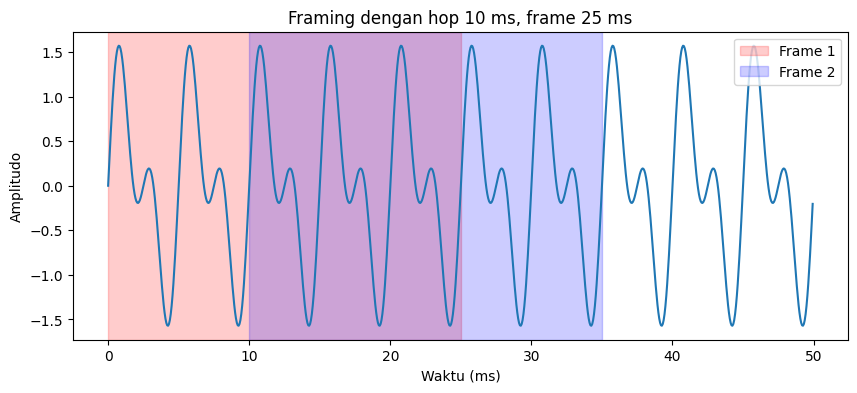

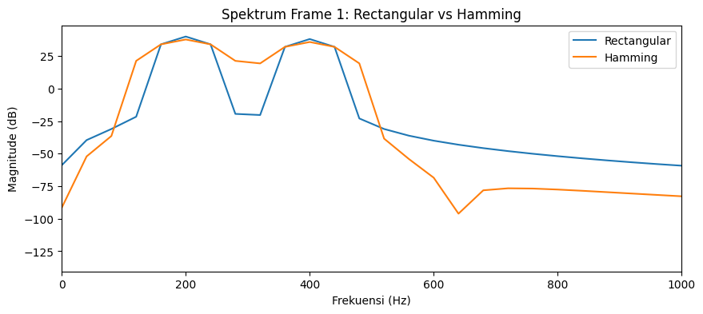

```python
import numpy as np
import matplotlib.pyplot as plt

# Parameter dasar
fs = 16000            # Frekuensi sampling (Hz)
dur = 0.05            # Durasi sinyal 50 ms
t = np.linspace(0, dur, int(fs*dur), endpoint=False)  # Vektor waktu

# Buat sinyal gabungan: sinus 200 Hz + 400 Hz
x = np.sin(2*np.pi*200*t) + 0.8*np.sin(2*np.pi*400*t)

# ================================
# Framing: potong sinyal menjadi frame-frame pendek
# ================================
N = int(0.025*fs)   # Panjang frame 25 ms → 400 sample
H = int(0.010*fs)   # Hop size 10 ms → 160 sample

frame1 = x[0:N]          # Frame pertama: mulai dari awal
frame2 = x[H:H+N]        # Frame kedua: digeser 10 ms (160 sample)

# ================================
# Windowing functions
# ================================
def hamming(N):
    n = np.arange(N)
    # Rumus hamming window: 0.54 - 0.46 cos(2πn/(N-1))
    return 0.54 - 0.46*np.cos(2*np.pi*n/(N-1))

rect = np.ones(N)   # Rectangular window (semua = 1)
hamm = hamming(N)   # Hamming window

# ================================
# Fungsi untuk menghitung FFT
# ================================
def compute_fft(sig, fs):
    N = len(sig)
    # FFT real-valued (positif frekuensi saja)
    X = np.fft.rfft(sig * np.hanning(N))
    freqs = np.fft.rfftfreq(N, 1/fs)      # Vektor frekuensi
    return freqs, np.abs(X)               # Magnitude spektrum

# ================================
# Plot posisi frame dalam domain waktu
# ================================
plt.figure(figsize=(10,4))
plt.plot(t*1000, x)  # Plot sinyal dalam ms
plt.axvspan(0, 25, color='red', alpha=0.2, label="Frame 1")   # Frame 1: 0–25 ms
plt.axvspan(10, 35, color='blue', alpha=0.2, label="Frame 2") # Frame 2: 10–35 ms
plt.title("Framing dengan hop 10 ms, frame 25 ms")
plt.xlabel("Waktu (ms)")
plt.ylabel("Amplitudo")
plt.legend()
plt.show()

# ================================
# Bandingkan spektrum dengan Rectangular vs Hamming window
# ================================
freqs, X_rect = compute_fft(frame1*rect, fs)  # FFT dengan Rectangular window
_, X_hamm = compute_fft(frame1*hamm, fs)      # FFT dengan Hamming window

plt.figure(figsize=(10,4))
plt.plot(freqs, 20*np.log10(X_rect+1e-9), label="Rectangular")  # Magnitude (dB)
plt.plot(freqs, 20*np.log10(X_hamm+1e-9), label="Hamming")
plt.xlim(0,1000)   # Fokus pada 0–1000 Hz
plt.title("Spektrum Frame 1: Rectangular vs Hamming")
plt.xlabel("Frekuensi (Hz)")
plt.ylabel("Magnitude (dB)")
plt.legend()
plt.show()
```

1. Grafik pertama: frame 25 ms ditampilkan dengan hop 10 ms → terlihat overlap.
2. Grafik kedua: hasil FFT dengan window Rectangular vs Hamming → Rectangular menunjukkan sidelobe yang lebih kuat (kebocoran), sedangkan Hamming lebih bersih pada frekuensi 200 Hz & 400 Hz.

### Contoh Soal

**Soal 1 (Numerik – Hitung Frame):** Audio berdurasi 5,2 s pada 16 kHz dianalisis dengan frame 25 ms dan hop 10 ms.  
(a) Berapa N (sampel/frame), H (hop sampel), dan jumlah frame?  
(b) Berapa overlap-nya?  
(c) Waktu (detik) saat awal frame ke-123?

**Soal 2 (Konseptual – Window):** Bandingkan karakteristik Rectangular, Hann, Hamming dalam konteks analisis spektral. Apa trade-off utamanya dan kapan masing-masing dipakai?

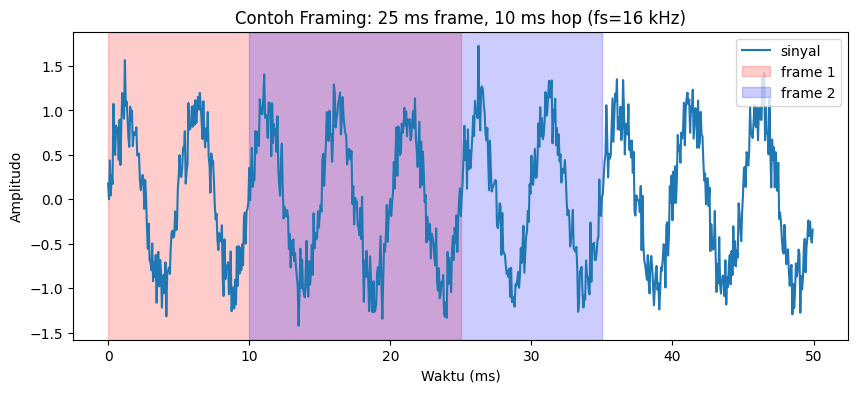

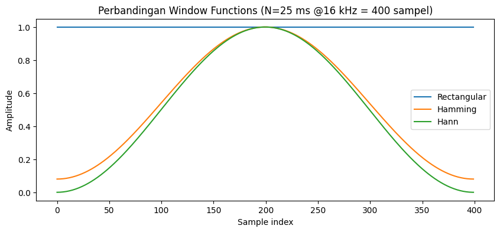

```python
import numpy as np
import matplotlib.pyplot as plt

# Sampling rate
fs = 16000          # frekuensi sampling 16 kHz
dur = 0.05          # durasi sinyal 50 ms
t = np.linspace(0, dur, int(fs*dur), endpoint=False)

# contoh sinyal: sinus 200 Hz + noise Gaussian (0.2 amplitudo)
x = np.sin(2*np.pi*200*t) + 0.2*np.random.randn(len(t))

# === Framing ===
# Panjang frame: 25 ms -> N = 0.025*fs = 400 sampel
N = int(fs*0.025)
# Hop size: 10 ms -> H = 0.010*fs = 160 sampel
H = int(fs*0.010)

# Ambil frame pertama (0–25 ms) dan frame kedua (10–35 ms)
frame1 = x[0:N]
frame2 = x[H:H+N]

# === Window functions ===
def hamming(N):
    # Rumus Hamming window
    n = np.arange(N)
    return 0.54 - 0.46*np.cos(2*np.pi*n/(N-1))

def hann(N):
    # Rumus Hann window
    n = np.arange(N)
    return 0.5*(1-np.cos(2*np.pi*n/(N-1)))

# Buat tiga jenis window
win_rect = np.ones(N)     # Rectangular (tanpa tapering)
win_hamm = hamming(N)     # Hamming window
win_hann = hann(N)        # Hann window

# === Plot 1: Sinyal + posisi frame ===
plt.figure(figsize=(10,4))
plt.plot(t*1000, x, label="sinyal")    # plot sinyal dalam ms
# Tandai frame 1 (0–25 ms) dengan warna merah transparan
plt.axvspan(0, 25, color='red', alpha=0.2, label='frame 1')
# Tandai frame 2 (10–35 ms) dengan warna biru transparan
plt.axvspan(10, 35, color='blue', alpha=0.2, label='frame 2')
plt.title("Contoh Framing: 25 ms frame, 10 ms hop (fs=16 kHz)")
plt.xlabel("Waktu (ms)")
plt.ylabel("Amplitudo")
plt.legend()
plt.show()

# === Plot 2: Window Functions ===
plt.figure(figsize=(10,4))
plt.plot(win_rect, label="Rectangular")  # window kotak
plt.plot(win_hamm, label="Hamming")      # window hamming
plt.plot(win_hann, label="Hann")         # window hann
plt.title("Perbandingan Window Functions (N=25 ms @16 kHz = 400 sampel)")
plt.xlabel("Sample index")
plt.ylabel("Amplitude")
plt.legend()
plt.show()
```

1. Grafik 1: Contoh Framing dengan frame 25 ms dan hop 10 ms → terlihat overlap antar frame.
2. Grafik 2: Perbandingan Window Functions (Rectangular, Hamming, Hann) → menunjukkan bentuk fungsi jendela untuk 400 sampel pada 25 ms dengan sampling rate 16 kHz.

## Speech Descriptors - Low Level Descriptors (LLD) Bagian 1

### Intensitas (Intensity)

#### Konsep Dasar

Intensitas adalah ukuran energi suara yang mencerminkan seberapa keras atau lemah suatu sinyal audio. Dalam analisis akustik, intensitas sering didekati dengan energi fisik sinyal karena lebih mudah dihitung dibandingkan persepsi loudness manusia yang kompleks.  
Parameter ini menjadi dasar untuk

- Deteksi aktivitas suara (Voice Activity Detection),
- Pembedaan antara segmen voiced/unvoiced/silence,
- Serta analisis karakteristik emosional pada ucapan.

#### Rumus Matematika

##### Energi Total

$$E = \sum_{k=-\infty}^{+\infty} s^2(k)$$

dimana:

- $s(k)$ = nilai amplitudo pada sampel ke-k
- $E$ = energi total sinyal

##### Energi per Frame (Short-time Energy)

$$E(n) = \sum_{k=n-\frac{N}{2}}^{n+\frac{N}{2}-1} [s(k) \cdot w(n-k-1)]^2$$

dimana:

- $n$ = indeks frame
- $w(\tau)$ = fungsi window
- $N$ = panjang frame

##### RMS Energy

$$E_{rms}(n) = \sqrt{\frac{1}{N} \sum_{k=n-\frac{N}{2}}^{n+\frac{N}{2}-1} [s(k) \cdot w(n-k-1)]^2}$$

##### Average Absolute Amplitude (AAA)

$$A(n) = \frac{1}{N} \sum_{k=n-\frac{N}{2}}^{n+\frac{N}{2}-1} |s(k) \cdot w(n-k-1)|$$

### Contoh Perhitungan

**Kasus:** Frame dengan 400 sampel pada sampling rate 16 kHz (durasi 25 ms)

**Interpretasi nilai:**

- Energi tinggi (>0.5): segmen voiced yang kuat
- Energi sedang (0.01-0.5): ucapan normal
- Energi rendah (<0.01): silence atau whisper

### Aplikasi

1. **Voice Activity Detection (VAD)**: Threshold energi untuk membedakan speech/non-speech
2. **Segmentasi audio**: Memisahkan kata atau frasa berdasarkan pola energi
3. **Analisis emosi**: Energi tinggi sering berkorelasi dengan arousal/excitement
4. **Speech enhancement**: Estimasi SNR berdasarkan distribusi energi

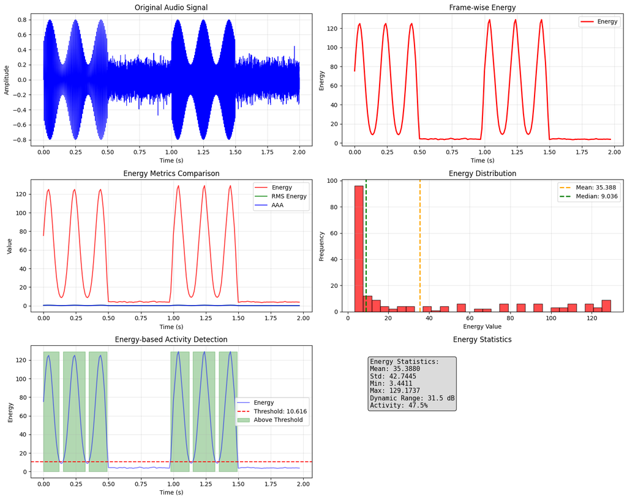

```python
import matplotlib.pyplot as plt
import numpy as np

# === Fungsi perhitungan energi dasar ===
def compute_energy(frame):
    """Hitung total energi frame (jumlah kuadrat sampel)"""
    return np.sum(frame**2)

def compute_rms_energy(frame):
    """Hitung RMS energy frame"""
    return np.sqrt(np.mean(frame**2))

def compute_aaa(frame):
    """Hitung Average Absolute Amplitude (rata-rata nilai absolut)"""
    return np.mean(np.abs(frame))

# Contoh penggunaan pada array kecil
frame = np.array([0.1, -0.2, 0.3, -0.1, 0.05])
energy = compute_energy(frame)           # 0.155
rms = compute_rms_energy(frame)          # 0.176
aaa = compute_aaa(frame)                 # 0.15

# === Fungsi utama untuk visualisasi analisis energi ===
def visualize_energy_analysis(audio_signal, fs, frame_length=400, hop_length=160):
    """
    Visualisasi analisis energi sinyal audio:
    - Sinyal asli
    - Energi per frame
    - Perbandingan metrik energi
    - Distribusi energi
    - Deteksi aktivitas berbasis energi
    - Statistik energi
    """

    fig, axes = plt.subplots(3, 2, figsize=(15, 12))

    # 1. Plot sinyal asli
    time_axis = np.arange(len(audio_signal)) / fs
    axes[0,0].plot(time_axis, audio_signal, 'b-', linewidth=0.8)
    axes[0,0].set_title('Original Audio Signal')
    axes[0,0].set_xlabel('Time (s)')
    axes[0,0].set_ylabel('Amplitude')
    axes[0,0].grid(True, alpha=0.3)

    # 2. Hitung energi, RMS, dan AAA tiap frame
    energies = []
    rms_energies = []
    aaa_values = []
    frame_times = []

    for i in range(0, len(audio_signal) - frame_length, hop_length):
        frame = audio_signal[i:i+frame_length]
        energies.append(compute_energy(frame))
        rms_energies.append(compute_rms_energy(frame))
        aaa_values.append(compute_aaa(frame))
        frame_times.append(i / fs)   # waktu awal frame

    # Plot energi per frame
    axes[0,1].plot(frame_times, energies, 'r-', linewidth=2, label='Energy')
    axes[0,1].set_title('Frame-wise Energy')
    axes[0,1].set_xlabel('Time (s)')
    axes[0,1].set_ylabel('Energy')
    axes[0,1].grid(True, alpha=0.3)
    axes[0,1].legend()

    # 3. Perbandingan metrik energi (Energy, RMS, AAA)
    axes[1,0].plot(frame_times, energies, 'r-', label='Energy', alpha=0.8)
    axes[1,0].plot(frame_times, rms_energies, 'g-', label='RMS Energy', alpha=0.8)
    axes[1,0].plot(frame_times, aaa_values, 'b-', label='AAA', alpha=0.8)
    axes[1,0].set_title('Energy Metrics Comparison')
    axes[1,0].set_xlabel('Time (s)')
    axes[1,0].set_ylabel('Value')
    axes[1,0].legend()
    axes[1,0].grid(True, alpha=0.3)

    # 4. Distribusi energi (histogram + mean + median)
    axes[1,1].hist(energies, bins=30, alpha=0.7, color='red', edgecolor='black')
    axes[1,1].axvline(np.mean(energies), color='orange', linestyle='--', linewidth=2,
                      label=f'Mean: {np.mean(energies):.3f}')
    axes[1,1].axvline(np.median(energies), color='green', linestyle='--', linewidth=2,
                      label=f'Median: {np.median(energies):.3f}')
    axes[1,1].set_title('Energy Distribution')
    axes[1,1].set_xlabel('Energy Value')
    axes[1,1].set_ylabel('Frequency')
    axes[1,1].legend()
    axes[1,1].grid(True, alpha=0.3)

    # 5. Deteksi aktivitas berbasis energi
    threshold = np.mean(energies) * 0.3  # ambang batas sederhana
    voiced_frames = np.array(energies) > threshold

    axes[2,0].plot(frame_times, energies, 'b-', alpha=0.5, label='Energy')
    axes[2,0].axhline(threshold, color='red', linestyle='--', label=f'Threshold: {threshold:.3f}')
    axes[2,0].fill_between(frame_times, 0, np.max(energies),
                          where=voiced_frames, alpha=0.3, color='green',
                          label='Above Threshold')
    axes[2,0].set_title('Energy-based Activity Detection')
    axes[2,0].set_xlabel('Time (s)')
    axes[2,0].set_ylabel('Energy')
    axes[2,0].legend()
    axes[2,0].grid(True, alpha=0.3)

    # 6. Statistik energi global
    stats_text = f"""Energy Statistics:
Mean: {np.mean(energies):.4f}
Std: {np.std(energies):.4f}
Min: {np.min(energies):.4f}
Max: {np.max(energies):.4f}
Dynamic Range: {20*np.log10(np.max(energies)/np.min(energies)):.1f} dB
Activity: {np.sum(voiced_frames)/len(voiced_frames)*100:.1f}%"""

    axes[2,1].text(0.1, 0.9, stats_text, transform=axes[2,1].transAxes,
                   fontsize=11, verticalalignment='top', fontfamily='monospace',
                   bbox=dict(boxstyle='round', facecolor='lightgray', alpha=0.8))
    axes[2,1].set_title('Energy Statistics')
    axes[2,1].axis('off')

    plt.tight_layout()
    plt.show()

# === Tes dengan sinyal simulasi ===
fs = 16000
duration = 2.0
t = np.linspace(0, duration, int(fs * duration))

# Buat sinyal 'ucapan' simulasi dengan variasi energi
speech_segments = []
for i in range(4):
    segment_start = i * duration / 4
    segment_end = (i + 1) * duration / 4
    segment_mask = (t >= segment_start) & (t < segment_end)

    if i % 2 == 0:  # Segmen voiced (berisi sinusoidal dengan amplitudo bervariasi)
        f0 = 150 + i * 20
        segment = np.sin(2*np.pi*f0*t[segment_mask]) * (0.5 + 0.3*np.sin(2*np.pi*5*t[segment_mask]))
    else:  # Segmen unvoiced / silence (noise rendah)
        segment = np.random.randn(np.sum(segment_mask)) * 0.1

    speech_segments.extend(segment)

# Gabungkan semua segmen jadi satu sinyal
speech_signal = np.array(speech_segments)

# Panggil fungsi visualisasi
visualize_energy_analysis(speech_signal, fs)
```

### Interpretasi Visual

1. Original Audio Signal (kiri-atas)

Gelombang waktu berisi bagian **voiced** (amplitudo besar, periodik) diselingi segmen **lemah/bising**. Ini akan tampak sebagai **puncak energi** vs **lantai energi** pada panel lain.

2. Frame-wise Energy (kanan-atas)

Energi per frame $E=\sum_n w[n]\,x^2[n]$ melonjak jelas pada segmen voiced dan mendekati nol pada bagian tidak bernada/senyap. Puncak-puncak yang periodik menunjukkan **amplitudo modulasi** dari sinyal.

3. Energy Metrics Comparison (kiri-tengah)

Histogram sangat **skewed ke kanan**: banyak frame berenergi rendah, sedikit frame berenergi tinggi. **Mean > median** → distribusi miring; cocok dengan sinyal yang sebagian besar lemah lalu sesekali kuat (voiced bursts).

5. Energy-based Activity Detection (kiri-bawah)

Ambang energi (garis putus merah, ≈ **10.6**) memisahkan **aktif** (hijau) vs **non-aktif**. Segmen hijau berimpit dengan puncak pada panel 2 — artinya deteksi aktivitas berbasis energi bekerja baik untuk sinyal ini.

6. Energy Statistics (kanan-bawah)

**Statistik Energi dan Aktivitas (kanan-bawah):**

Rangkuman numerik menunjukkan karakteristik distribusi energi yang sangat informatif. **Mean energi 35.39** yang jauh lebih besar dibanding **median 9.04** mengindikasikan distribusi yang **strongly right-skewed**, artinya mayoritas frame memiliki energi rendah dengan beberapa frame berenergi sangat tinggi (burst voiced). **Standar deviasi 42.75** yang besar menunjukkan **variabilitas tinggi** antar frame, konsisten dengan sifat sinyal ucapan yang bergantian antara aktif dan pasif.

Energi merupakan **indikator keaktifan** yang sangat efektif dimana nilai tinggi menunjukkan segmen **voiced/aktif** sementara nilai rendah mengindikasikan **unvoiced/silence**. Dalam pemilihan metrik, **RMS/AAA** berguna ketika menginginkan hasil yang **stabil** dan robust terhadap outlier, sedangkan **energy** mentah bagus untuk deteksi cepat meski lebih sensitif terhadap nilai ekstrem. Untuk **thresholding**, disarankan menggunakan ambang adaptif seperti median + k·MAD, persentil 80-90, atau metode Otsu agar tahan terhadap perubahan level sinyal. **Log-energy** (10log₁₀E) sering membuat distribusi lebih "normal" dan memudahkan pemisahan kelas. Kombinasi **Energi + ZCR** memberikan klasifikasi yang lebih robust: tinggi-energi & ZCR rendah mengindikasikan **voiced**, rendah-energi menunjukkan **silence**, sedangkan ZCR tinggi & energi menengah mengindikasikan **unvoiced/noise**. Singkatnya, keenam panel menunjukkan bahwa **intensitas** berhasil memetakan kapan sinyal **aktif**, memberikan **kontras yang tajam** antara voiced dan non-voiced, dan dengan ambang yang tepat dapat digunakan sebagai **VAD (voice activity detection)** sederhana namun efektif.

### Konsep Dasar

Zero Crossing Rate mengukur frekuensi perubahan tanda sinyal dalam satu frame, memberikan informasi kasar tentang kandungan frekuensi sinyal. ZCR berguna untuk membedakan voiced speech (ZCR rendah) dari unvoiced speech (ZCR tinggi) dan mendeteksi transisi antar fonem.

### Formula Matematika

#### ZCR Dasar

$$ZCR(n) = \frac{1}{N} \sum_{k=n-\frac{N}{2}+1}^{n+\frac{N}{2}} |\text{sgn}[s(k)] - \text{sgn}[s(k-1)]|$$

dimana:

- $\text{sgn}[x] = \begin{cases} +1 & \text{jika } x > 0 \\ -1 & \text{jika } x < 0 \\ 0 & \text{jika } x = 0 \end{cases}$
- $N$ = panjang frame

#### Implementasi

$$ZCR(n) = \frac{1}{N} \sum_{k=n-\frac{N}{2}+1}^{n+\frac{N}{2}} s_0(k)$$

dimana: $$s_0(k) = \begin{cases} 1 & \text{jika } \text{sgn}[s(k)] \neq \text{sgn}[s(k-1)] \\ 0 & \text{sebaliknya} \end{cases}$$

#### Hubungan dengan Frekuensi

Untuk sinyal sinus murni dengan frekuensi $f$: $$ZCR \approx \frac{2f}{f_s}$$

dimana $f_s$ = sampling rate

### Karakteristik ZCR untuk Berbagai Sinyal

| Jenis Sinyal | ZCR Range | Karakteristik |
| --- | --- | --- |
| Voiced speech (vokal) | 0.02 - 0.08 | Periodik, frekuensi rendah |
| Unvoiced speech (frikatif) | 0.15 - 0.5 | Noise-like, frekuensi tinggi |
| Music (harmonik) | 0.05 - 0.2 | Bergantung pada instrumen |
| White noise | ≈ 0.5 | Random sign changes |

[output not shown]

### Keterbatasan ZCR

1. **Sensitivitas noise**: Noise dapat meningkatkan ZCR secara artifisial
2. **Aliasing**: Frekuensi tinggi yang ter-alias dapat mempengaruhi perhitungan
3. **Overlapping karakteristik**: Beberapa voiced sound memiliki ZCR tinggi
4. **Threshold dependency**: Perlu penyesuaian threshold untuk kondisi berbeda

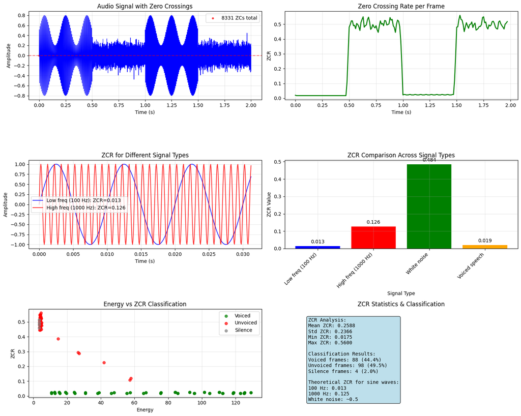

```python
def compute_zcr(frame):
    """Hitung Zero Crossing Rate (ZCR) untuk 1 frame"""
    # Ambil tanda (+/-) dari setiap sampel
    signs = np.sign(frame)
    # Hitung perubahan tanda antar sampel
    sign_changes = np.diff(signs)
    # Hitung jumlah zero crossing lalu normalisasi dengan panjang frame
    zcr = np.sum(sign_changes != 0) / len(frame)
    return zcr

def compute_zcr_windowed(audio, frame_length, hop_length):
    """Hitung ZCR untuk banyak frame (windowing)"""
    zcr_values = []
    for i in range(0, len(audio) - frame_length, hop_length):
        # Potong frame sesuai panjang dan hop
        frame = audio[i:i+frame_length]
        zcr_values.append(compute_zcr(frame))
    return np.array(zcr_values)

# ------------------- Contoh sederhana -------------------
# Sinyal sinus 1000 Hz dengan fs=16 kHz
fs = 16000
t = np.linspace(0, 0.1, int(fs*0.1))
signal_sine = np.sin(2*np.pi*1000*t)
zcr_sine = compute_zcr(signal_sine)  # ~0.125 (≈ 2*1000/16000)

# Sinyal noise putih
signal_noise = np.random.randn(1600)
zcr_noise = compute_zcr(signal_noise)  # ~0.5 (karena acak)

# ------------------- Visualisasi ZCR -------------------
def visualize_zcr_analysis(audio_signal, fs, frame_length=400, hop_length=160):
    """Visualisasi analisis ZCR: sinyal, per frame, klasifikasi, statistik"""

    fig, axes = plt.subplots(3, 2, figsize=(15, 12))

    # 1. Plot sinyal asli + titik zero crossing
    time_axis = np.arange(len(audio_signal)) / fs
    axes[0,0].plot(time_axis, audio_signal, 'b-', linewidth=0.8)
    axes[0,0].axhline(0, color='red', linestyle='--', alpha=0.5)

    # Tandai titik zero crossing
    zero_crossings = []
    for i in range(1, len(audio_signal)):
        if np.sign(audio_signal[i]) != np.sign(audio_signal[i-1]):
            zero_crossings.append(i)

    if len(zero_crossings) > 0:
        zc_times = np.array(zero_crossings) / fs
        axes[0,0].scatter(zc_times[:50], np.zeros(min(50, len(zc_times))),
                         color='red', s=10, alpha=0.7, label=f'{len(zero_crossings)} ZCs total')

    axes[0,0].set_title('Audio Signal with Zero Crossings')
    axes[0,0].set_xlabel('Time (s)')
    axes[0,0].set_ylabel('Amplitude')
    axes[0,0].legend()
    axes[0,0].grid(True, alpha=0.3)

    # 2. Hitung & plot ZCR per frame
    zcr_values = []
    frame_times = []
    for i in range(0, len(audio_signal) - frame_length, hop_length):
        frame = audio_signal[i:i+frame_length]
        zcr_values.append(compute_zcr(frame))
        frame_times.append(i / fs)

    axes[0,1].plot(frame_times, zcr_values, 'g-', linewidth=2)
    axes[0,1].set_title('Zero Crossing Rate per Frame')
    axes[0,1].set_xlabel('Time (s)')
    axes[0,1].set_ylabel('ZCR')
    axes[0,1].grid(True, alpha=0.3)

    # 3. Bandingkan beberapa sinyal dengan ZCR berbeda
    t_short = np.linspace(0, 0.1, int(fs * 0.1))
    signals = {
        'Low freq (100 Hz)': np.sin(2*np.pi*100*t_short),
        'High freq (1000 Hz)': np.sin(2*np.pi*1000*t_short),
        'White noise': np.random.randn(len(t_short)) * 0.5,
        'Voiced speech': np.sin(2*np.pi*150*t_short) * (1 + 0.5*np.sin(2*np.pi*500*t_short))
    }

    colors = ['blue', 'red', 'green', 'orange']
    zcr_comparison = []

    for idx, (name, sig) in enumerate(signals.items()):
        zcr_val = compute_zcr(sig)
        zcr_comparison.append(zcr_val)
        if idx < 2:  # hanya plot 2 pertama biar jelas
            axes[1,0].plot(t_short[:500], sig[:500], color=colors[idx],
                          label=f'{name}: ZCR={zcr_val:.3f}', alpha=0.8)

    axes[1,0].set_title('ZCR for Different Signal Types')
    axes[1,0].set_xlabel('Time (s)')
    axes[1,0].set_ylabel('Amplitude')
    axes[1,0].legend()
    axes[1,0].grid(True, alpha=0.3)

    # 4. Diagram batang perbandingan ZCR
    signal_names = list(signals.keys())
    axes[1,1].bar(range(len(zcr_comparison)), zcr_comparison, color=colors[:len(zcr_comparison)])
    axes[1,1].set_title('ZCR Comparison Across Signal Types')
    axes[1,1].set_xlabel('Signal Type')
    axes[1,1].set_ylabel('ZCR Value')
    axes[1,1].set_xticks(range(len(signal_names)))
    axes[1,1].set_xticklabels(signal_names, rotation=45, ha='right')
    axes[1,1].grid(True, alpha=0.3)

    # Tampilkan nilai ZCR di atas bar
    for i, v in enumerate(zcr_comparison):
        axes[1,1].text(i, v + 0.01, f'{v:.3f}', ha='center', va='bottom')

    # 5. Scatter plot klasifikasi berdasarkan Energy & ZCR
    energies = []
    for i in range(0, len(audio_signal) - frame_length, hop_length):
        frame = audio_signal[i:i+frame_length]
        energies.append(compute_energy(frame))

    energies = np.array(energies)
    zcr_values = np.array(zcr_values)

    # Aturan sederhana klasifikasi
    voiced_mask = (energies > np.mean(energies) * 0.3) & (zcr_values < 0.1)
    unvoiced_mask = (energies > np.mean(energies) * 0.1) & (zcr_values >= 0.1)
    silence_mask = energies <= np.mean(energies) * 0.1

    axes[2,0].scatter(energies[voiced_mask], zcr_values[voiced_mask],
                     color='green', label='Voiced', alpha=0.7, s=30)
    axes[2,0].scatter(energies[unvoiced_mask], zcr_values[unvoiced_mask],
                     color='red', label='Unvoiced', alpha=0.7, s=30)
    axes[2,0].scatter(energies[silence_mask], zcr_values[silence_mask],
                     color='gray', label='Silence', alpha=0.7, s=30)

    axes[2,0].set_xlabel('Energy')
    axes[2,0].set_ylabel('ZCR')
    axes[2,0].set_title('Energy vs ZCR Classification')
    axes[2,0].legend()
    axes[2,0].grid(True, alpha=0.3)

    # 6. Statistik ZCR & hasil klasifikasi
    stats_text = f"""ZCR Analysis:
Mean ZCR: {np.mean(zcr_values):.4f}
Std ZCR: {np.std(zcr_values):.4f}
Min ZCR: {np.min(zcr_values):.4f}
Max ZCR: {np.max(zcr_values):.4f}

Classification Results:
Voiced frames: {np.sum(voiced_mask)} ({np.sum(voiced_mask)/len(zcr_values)*100:.1f}%)
Unvoiced frames: {np.sum(unvoiced_mask)} ({np.sum(unvoiced_mask)/len(zcr_values)*100:.1f}%)
Silence frames: {np.sum(silence_mask)} ({np.sum(silence_mask)/len(zcr_values)*100:.1f}%)

Theoretical ZCR for sine waves:
100 Hz: {2*100/fs:.3f}
1000 Hz: {2*1000/fs:.3f}
White noise: ~0.5"""

    axes[2,1].text(0.1, 0.9, stats_text, transform=axes[2,1].transAxes,
                   fontsize=10, verticalalignment='top', fontfamily='monospace',
                   bbox=dict(boxstyle='round', facecolor='lightblue', alpha=0.8))
    axes[2,1].set_title('ZCR Statistics & Classification')
    axes[2,1].axis('off')

    plt.tight_layout()
    plt.show()

# ------------------- Uji Visualisasi -------------------
visualize_zcr_analysis(speech_signal, fs)
```

### Intepretasi Visual

1. Audio Signal with Zero Crossings (kiri-atas)

2. Zero Crossing Rate per Frame (kanan-atas)

Bar chart merangkum:

- Low-freq sine < High-freq sine < **White noise (tertinggi, ≈0.48–0.5)**.
- **Voiced speech** sangat rendah (≈0.02). Kesimpulan: **Noise** mendekati batas teoritis ZCR **0.5** (peluang sama positif/negatif), sementara **voiced** sangat kecil.
5. Energy vs ZCR Classification (kiri-bawah)

**Indikator kebernadaan**: ZCR **rendah** → voiced/periodik berfrekuensi rendah-menengah; ZCR **tinggi** → unvoiced/noise/konsonan frikatif. **Indikator frekuensi kasar**: makin tinggi frekuensi dominan, **makin tinggi ZCR**. * **Kombinasikan dengan energi** untuk pemisahan voiced/unvoiced/silence yang lebih andal (terlihat jelas pada scatter).

ZCR sangat peka terhadap **noise**, **DC offset**, dan **ukuran window**—window terlalu pendek membuat ZCR “gelisah”. Untuk speech tipikal, gunakan frame 20–30 ms, hop 10 ms, dan lakukan pre-emphasis/DC-removal. Ambang contoh (tuning tergantung data): ZCR < ~0.05 & energi tinggi → voiced; ZCR > ~0.15 → unvoiced; energi sangat rendah → silence. Dengan membaca keenam panel ini, ZCR jelas memetakan kapan sinyal bernada vs tak bernada, seberapa kasar frekuensinya, dan—bila digabung energi—memberi klasifikasi per-frame yang cukup akurat.

### Contoh Aplikasi

```python
#### Klasifikasi Voiced/Unvoiced

def classify_speech_type(energy, zcr, energy_threshold=0.01, zcr_threshold=0.1):
    """
    Klasifikasi jenis speech berdasarkan energy dan ZCR:
    - silence   : energi sangat rendah (hampir tidak ada suara)
    - voiced    : energi tinggi, ZCR rendah (suara vokal/konsonan bersuara)
    - unvoiced  : energi ada, tapi ZCR tinggi (frikatif / konsonan tak bersuara)
    """
    if energy < energy_threshold:
        return "silence"   # Hampir tidak ada energi → diam
    elif energy > energy_threshold and zcr < zcr_threshold:
        return "voiced"    # Energi tinggi + ZCR rendah → vokal/konsonan bersuara
    elif energy > energy_threshold and zcr >= zcr_threshold:
        return "unvoiced"  # Energi ada + ZCR tinggi → konsonan tak bersuara (fricative, plosive)
    else:
        return "unknown"   # fallback jika tidak memenuhi kondisi

# === Contoh penggunaan ===
# Frame voiced: sinusoidal 150 Hz → meniru vokal
frame_voiced = np.sin(2*np.pi*150*t)

# Frame unvoiced: noise acak → meniru bunyi fricative (misal /s/, /f/)
frame_unvoiced = np.random.randn(400) * 0.1

# Hitung energy dan ZCR
energy_v = compute_energy(frame_voiced)     # Harus tinggi
zcr_v = compute_zcr(frame_voiced)           # Harus rendah (~0.02)

energy_uv = compute_energy(frame_unvoiced)  # Sedang-tinggi
zcr_uv = compute_zcr(frame_unvoiced)        # Tinggi (~0.5)

# Cetak hasil klasifikasi
print(classify_speech_type(energy_v, zcr_v))    # → "voiced"
print(classify_speech_type(energy_uv, zcr_uv))  # → "unvoiced"
```

```
voiced
unvoiced
```

### Auto Correlation Function (ACF)

#### Konsep Dasar

Autokorelasi mengukur similaritas sinyal dengan dirinya sendiri ketika digeser dengan delay tertentu. ACF sangat efektif untuk mendeteksi periodisitas dalam sinyal ucapan, estimasi pitch, dan membedakan voiced/unvoiced speech. Untuk sinyal periodik, ACF juga akan periodik dengan periode yang sama.

#### Rumus Matematika

##### Autokorelasi Tak Terbatas

$$R(d) = \sum_{k=-\infty}^{+\infty} s(k) \cdot s(k + d)$$

dimana:

- $d$ = parameter delay (lag)
- $R(d)$ = nilai autokorelasi pada delay d

##### Autokorelasi Ternormalisasi

$$r(d) = \frac{R(d)}{R(0)}$$

dimana:

- $R(0)$ = energi total sinyal (maksimum global)
- $r(d) \in [-1, +1]$

##### Short-Time Autocorrelation (Pendekatan Stasioner)

$$R(n,d) = \sum_{k=-\infty}^{+\infty} s(k) \cdot w(n-k-1) \cdot s(k+d) \cdot w(n-k-1-d)$$

dimana sinyal dibobot dua kali dengan window $w(\tau)$.

##### Short-Time Autocorrelation (Pendekatan Non-Stasioner)

$$R(n,d) = \sum_{k=-\infty}^{+\infty} s(k) \cdot s(k+d) \cdot w(n-k-1)$$

dimana hanya satu pembobotan diterapkan, mengurangi efek fading.

##### Harmonics-to-Noise Ratio (HNR)

$$HNR = 10 \log_{10} \left(\frac{ACF(T_0)}{ACF(0) - ACF(T_0)}\right)$$

dimana $T_0$ adalah periode fundamental dalam sampel.

#### Sifat-sifat Penting ACF

1. **Simetri**: $R(-d) = R(d)$
2. **Maksimum di lag 0**: $R(0) \geq |R(d)|$ untuk semua $d$
3. **Periodisitas**: Jika $s(k)$ periodik dengan periode $T$, maka $R(d+T) = R(d)$
4. **Invariansi fase**: Struktur periodik tidak berubah meski window digeser

#### Aplikasi Praktis ACF

1. **Pitch tracking**: Fundamental untuk analisis prosodi dan musik
2. **Speaker identification**: Pola ACF karakteristik untuk setiap speaker
3. **Speech/Music discrimination**: Periodisitas berbeda antara speech dan musik
4. **Voice quality assessment**: HNR untuk evaluasi patologi suara
5. **Echo detection**: Deteksi delay dalam sistem audio

```python
def compute_autocorrelation(signal, max_lag=None):
    """Hitung autokorelasi menggunakan numpy correlate"""
    if max_lag is None:
        max_lag = len(signal) - 1

    # Autokorelasi penuh (lag negatif & positif)
    autocorr_full = np.correlate(signal, signal, mode='full')

    # Ambil hanya bagian lag ≥ 0 (positif)
    center = len(autocorr_full) // 2
    autocorr = autocorr_full[center:center+max_lag+1]

    return autocorr

def compute_normalized_autocorr(signal, max_lag=None):
    """Autokorelasi ternormalisasi"""
    autocorr = compute_autocorrelation(signal, max_lag)

    # Normalisasi: bagi dengan nilai pada lag=0 (energi total sinyal)
    if autocorr[0] != 0:
        normalized = autocorr / autocorr[0]
    else:
        normalized = autocorr

    return normalized

def find_pitch_from_autocorr(autocorr, fs, f0_min=75, f0_max=400):
    """Estimasi F0 (pitch) dari autokorelasi"""

    # Konversi batas frekuensi → lag
    lag_min = int(fs / f0_max)   # lag minimum (pitch tertinggi)
    lag_max = int(fs / f0_min)   # lag maksimum (pitch terendah)

    # Cari puncak di dalam rentang lag valid
    if lag_max < len(autocorr):
        search_region = autocorr[lag_min:lag_max]

        # Jika ada kandidat lag
        if len(search_region) > 0:
            # Ambil lag dengan puncak maksimum
            peak_idx = np.argmax(search_region) + lag_min

            # Konversi kembali lag → frekuensi
            f0_estimate = fs / peak_idx
            confidence = autocorr[peak_idx]  # nilai korelasi sebagai "kepercayaan"

            return f0_estimate, confidence

    # Jika gagal, return 0
    return 0, 0

# ------------------- TEST -------------------
# Setup parameter
fs = 16000
t = np.linspace(0, 0.1, int(fs*0.1))  # durasi 0.1 detik
f0 = 150  # Hz (pitch target)

# Sinyal voiced dengan harmonik
signal = (np.sin(2*np.pi*f0*t) +
          0.5*np.sin(2*np.pi*2*f0*t) +
          0.25*np.sin(2*np.pi*3*f0*t))

# Hitung autokorelasi ternormalisasi
autocorr = compute_normalized_autocorr(signal, 200)

# Estimasi pitch (F0)
f0_detected, conf = find_pitch_from_autocorr(autocorr, fs)

print(f"F0 detected: {f0_detected:.1f} Hz (actual: 150 Hz)")
print(f"Confidence: {conf:.3f}")
```

```
F0 detected: 0.0 Hz (actual: 150 Hz)
Confidence: 0.000
```

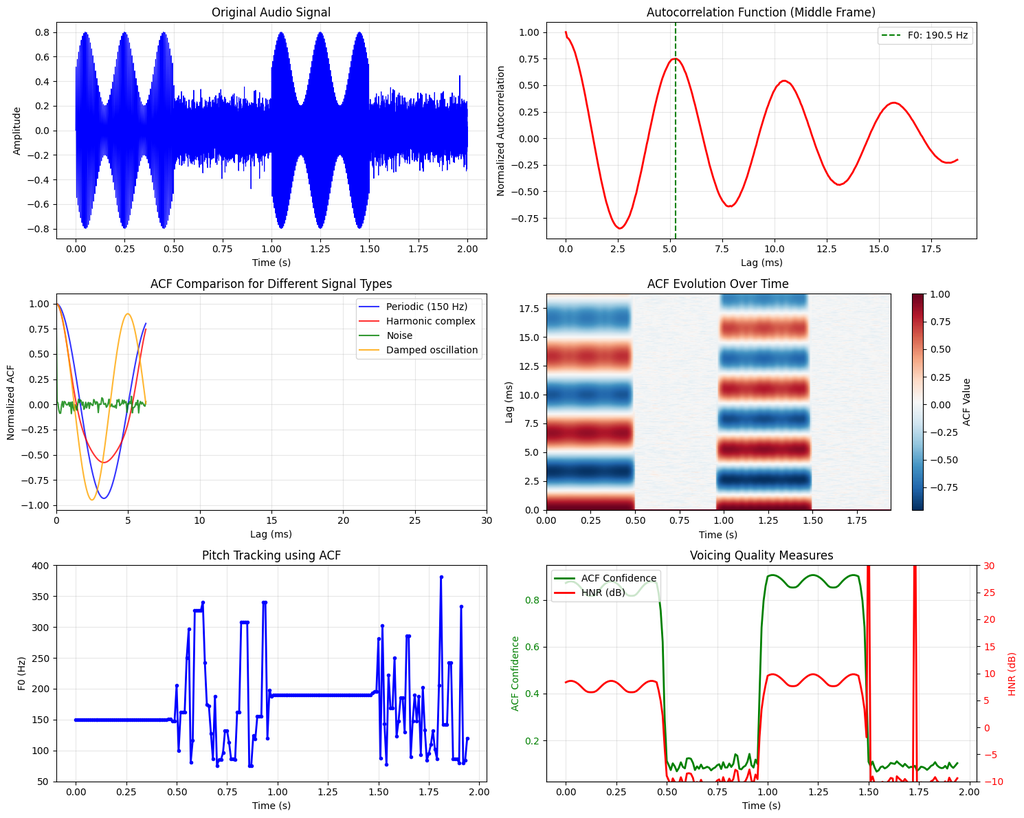

```python
def visualize_acf_analysis(audio_signal, fs, frame_length=800, max_lag=300):
    """Visualisasi analisis ACF komprehensif"""

    fig, axes = plt.subplots(3, 2, figsize=(15, 12))

    # 1. Plot sinyal audio asli (domain waktu)
    time_axis = np.arange(len(audio_signal)) / fs
    axes[0,0].plot(time_axis, audio_signal, 'b-', linewidth=0.8)
    axes[0,0].set_title('Original Audio Signal')
    axes[0,0].set_xlabel('Time (s)')
    axes[0,0].set_ylabel('Amplitude')
    axes[0,0].grid(True, alpha=0.3)

    # 2. Hitung ACF untuk 1 frame (di tengah sinyal)
    mid_frame_start = len(audio_signal) // 2 - frame_length // 2
    frame = audio_signal[mid_frame_start:mid_frame_start + frame_length]

    autocorr = compute_normalized_autocorr(frame, max_lag)
    lag_axis = np.arange(len(autocorr)) / fs * 1000  # Lag dalam ms

    axes[0,1].plot(lag_axis, autocorr, 'r-', linewidth=2)
    axes[0,1].set_title('Autocorrelation Function (Middle Frame)')
    axes[0,1].set_xlabel('Lag (ms)')
    axes[0,1].set_ylabel('Normalized Autocorrelation')
    axes[0,1].grid(True, alpha=0.3)

    # Estimasi pitch dari puncak ACF
    f0_est, confidence = find_pitch_from_autocorr(autocorr, fs)
    if f0_est > 0:
        pitch_lag_ms = 1000 / f0_est
        axes[0,1].axvline(pitch_lag_ms, color='green', linestyle='--',
                         label=f'F0: {f0_est:.1f} Hz')
        axes[0,1].legend()

    # 3. Bandingkan ACF untuk beberapa jenis sinyal buatan
    t_comp = np.linspace(0, 0.05, int(fs * 0.05))
    comparison_signals = {
        'Periodic (150 Hz)': np.sin(2*np.pi*150*t_comp),
        'Harmonic complex': np.sin(2*np.pi*150*t_comp) + 0.5*np.sin(2*np.pi*300*t_comp) + 0.25*np.sin(2*np.pi*450*t_comp),
        'Noise': np.random.randn(len(t_comp)) * 0.5,
        'Damped oscillation': np.sin(2*np.pi*200*t_comp) * np.exp(-3*t_comp)
    }

    colors = ['blue', 'red', 'green', 'orange']
    for idx, (name, sig) in enumerate(comparison_signals.items()):
        autocorr_comp = compute_normalized_autocorr(sig, min(100, len(sig)-1))
        lag_comp = np.arange(len(autocorr_comp)) / fs * 1000
        axes[1,0].plot(lag_comp, autocorr_comp, color=colors[idx],
                      label=name, linewidth=1.5, alpha=0.8)

    axes[1,0].set_title('ACF Comparison for Different Signal Types')
    axes[1,0].set_xlabel('Lag (ms)')
    axes[1,0].set_ylabel('Normalized ACF')
    axes[1,0].legend()
    axes[1,0].grid(True, alpha=0.3)
    axes[1,0].set_xlim(0, 30)

    # 4. Hitung Short-time ACF (per frame, bergeser dengan hop_length)
    hop_length = 160
    acf_evolution = []
    pitch_evolution = []
    confidence_evolution = []
    frame_times = []

    for i in range(0, len(audio_signal) - frame_length, hop_length):
        frame = audio_signal[i:i+frame_length]
        autocorr = compute_normalized_autocorr(frame, max_lag)
        acf_evolution.append(autocorr)

        # Simpan hasil tracking pitch & confidence
        f0_est, conf = find_pitch_from_autocorr(autocorr, fs)
        pitch_evolution.append(f0_est if f0_est > 50 else np.nan)
        confidence_evolution.append(conf)
        frame_times.append(i / fs)

    # Plot matriks ACF evolusi sepanjang waktu
    acf_matrix = np.array(acf_evolution).T
    im = axes[1,1].imshow(acf_matrix, aspect='auto', origin='lower', cmap='RdBu_r',
                         extent=[frame_times[0], frame_times[-1], 0, max_lag/fs*1000])
    axes[1,1].set_title('ACF Evolution Over Time')
    axes[1,1].set_xlabel('Time (s)')
    axes[1,1].set_ylabel('Lag (ms)')
    plt.colorbar(im, ax=axes[1,1], label='ACF Value')

    # 5. Pitch tracking dari ACF
    axes[2,0].plot(frame_times, pitch_evolution, 'b-', linewidth=2, marker='o', markersize=3)
    axes[2,0].set_title('Pitch Tracking using ACF')
    axes[2,0].set_xlabel('Time (s)')
    axes[2,0].set_ylabel('F0 (Hz)')
    axes[2,0].grid(True, alpha=0.3)
    axes[2,0].set_ylim(50, 400)

    # 6. Hitung HNR (Harmonics-to-Noise Ratio) per frame
    hnr_values = []
    for i, autocorr in enumerate(acf_evolution):
        if pitch_evolution[i] > 0 and not np.isnan(pitch_evolution[i]):
            pitch_lag = int(fs / pitch_evolution[i])
            if pitch_lag < len(autocorr):
                signal_power = autocorr[pitch_lag]
                noise_power = autocorr[0] - autocorr[pitch_lag]

                # Hindari error pembagian dengan bilangan sangat kecil
                if noise_power > 1e-10 and signal_power > 0:
                    ratio = signal_power / noise_power
                    if ratio > 0:
                        hnr = 10 * np.log10(ratio)
                        # Clamp nilai HNR biar tidak ekstrim
                        hnr = np.clip(hnr, -30, 50)
                        hnr_values.append(hnr)
                    else:
                        hnr_values.append(-30)
                else:
                    hnr_values.append(50)  # Noise hampir nol
            else:
                hnr_values.append(0)  # fallback
        else:
            hnr_values.append(0)  # frame unvoiced

    # Plot Confidence dan HNR
    ax2 = axes[2,1].twinx()

    axes[2,1].plot(frame_times, confidence_evolution, 'g-', linewidth=2, label='ACF Confidence')
    axes[2,1].set_xlabel('Time (s)')
    axes[2,1].set_ylabel('ACF Confidence', color='g')
    axes[2,1].tick_params(axis='y', labelcolor='g')

    ax2.plot(frame_times, hnr_values, 'r-', linewidth=2, label='HNR (dB)')
    ax2.set_ylabel('HNR (dB)', color='r')
    ax2.tick_params(axis='y', labelcolor='r')
    ax2.set_ylim(-10, 30)

    axes[2,1].set_title('Voicing Quality Measures')
    axes[2,1].grid(True, alpha=0.3)

    # Tambahin legend gabungan
    lines1, labels1 = axes[2,1].get_legend_handles_labels()
    lines2, labels2 = ax2.get_legend_handles_labels()
    axes[2,1].legend(lines1 + lines2, labels1 + labels2, loc='upper left')

    plt.tight_layout()
    plt.show()

# Contoh pemanggilan
visualize_acf_analysis(speech_signal, fs)
```

#### Intepretasi Visual

1. Original Audio Signal ( kiri-atas )

Gelombang waktunya terdiri dari bagian **voiced / periodik** (amplitudo jelas, berulang) diselingi bagian **tak beraturan** (lebih bising). Ini menandakan ada segmen bernada (punya F0) dan segmen tak bernada.

2. Autocorrelation (Middle Frame) ( kanan-atas )
- Kurva ACF selalu **1 di lag = 0** (sinyal berkorelasi sempurna dengan dirinya sendiri).
- **Puncak besar pertama** terjadi di lag ≈ **5.25 ms** (garis hijau). Periode $T_0$ ≈ 5.25 ms → **F0 ≈ 1/T0 ≈ 190.5 Hz** (tertera di legend).
- Puncak-puncak berikutnya di kira-kira kelipatan lag itu (≈ 10.5 ms, 15.8 ms, …) mengonfirmasi **periodisitas**. Amplitudonya **menurun** karena energi tak murni/harmonisa + efek window.

**Intinya:** satu frame di tengah benar-benar voiced; ACF menemukan periode dasar dengan jelas.

**Pelajaran:** ada/tidaknya puncak berulang di ACF adalah detektor sederhana “bernada vs tidak”.

4. ACF Evolution Over Time ( heatmap, kanan-tengah )

Sumbu-y = **lag (ms)**, sumbu-x = **waktu**. Garis/gugus warna panas (merah) yang **stabil di satu lag** menandakan periode tetap. Terlihat **pita panas** muncul di beberapa rentang waktu (voiced) dan **menghilang** di segmen lain (unvoiced/noisy). Lag pita utama sekitar **5–7 ms** → F0 sekitar **150–200 Hz** pada bagian voiced.

5. Pitch Tracking using ACF ( kiri-bawah )

Dua meter kualitas:

**Keduanya sejalan**: saat confidence naik, HNR juga naik → sinyal lebih harmonik/bernada.

Deteksi voiced dilakukan dengan mencari puncak ACF yang signifikan selain pada lag nol; nilai puncak ini dapat digunakan sebagai ukuran confidence. Estimasi pitch (F0) diperoleh dari $F0 = 1/T_0$, di mana $T_0$ adalah lag puncak pertama—misalnya pada frame tengah didapat sekitar 190.5 Hz. Stabilitas F0 sangat bergantung pada kualitas sinyal; pada bagian yang bising, confidence dan HNR akan turun sehingga estimasi F0 menjadi kurang reliabel. Visualisasi heatmap ACF sangat membantu untuk melihat perubahan pitch dan kebervoisan sepanjang waktu.

### Short-Time Autocorrelation Function (ST-ACF)

#### Konsep Dasar ST-ACF

Short-Time Autocorrelation Function adalah ekstensi dari ACF untuk sinyal non-stasioner seperti ucapan. Karena sinyal audio berubah sepanjang waktu, kita tidak dapat menggunakan ACF untuk keseluruhan sinyal. ST-ACF menghitung autokorelasi dalam jendela waktu pendek yang bergeser, memungkinkan analisis periodisitas lokal.

#### Motivasi dan Kebutuhan ST-ACF

Sinyal ucapan memiliki karakteristik yang berubah-ubah:

- **Pitch** berubah sesuai intonasi dan emosi
- **Voicing** bergantian antara voiced/unvoiced/silence
- **Spektral content** berubah seiring perubahan fonem
- **Durasi** setiap fonem berbeda-beda

#### Rumus Matematika ST-ACF

##### Pendekatan Stasioner (Stationary Approach)

$R_s(n,d) = \sum_{k=-\infty}^{+\infty} s(k) \cdot w(n-k-1) \cdot s(k+d) \cdot w(n-k-1-d)$

**Karakteristik:**

- Sinyal dibobot **dua kali** dengan window function
- Window diterapkan pada kedua bagian sinyal ($s(k)$ dan $s(k+d)$)
- Menghasilkan efek **fading** untuk lag yang besar
- Lebih **konservatif** dalam mempertahankan lokalitas temporal

##### Pendekatan Non-Stasioner (Non-Stationary Approach)

$R_{ns}(n,d) = \sum_{k=-\infty}^{+\infty} s(k) \cdot s(k+d) \cdot w(n-k-1)$

**Karakteristik:**

- Sinyal hanya dibobot **satu kali**
- Window hanya diterapkan pada lokasi referensi
- **Mengurangi efek fading** untuk lag besar
- Lebih mirip **cross-correlation**
- **Tidak simetris**: $R_{ns}(n,d) \neq R_{ns}(n,-d)$

#### Perbedaan Fundamental Kedua Pendekatan

| Aspek | Stasioner | Non-Stasioner |
| --- | --- | --- |
| **Windowing** | Double windowing | Single windowing |
| **Simetri** | Simetris | Non-simetris |
| **Fading effect** | Kuat | Lemah |
| **Computational cost** | Lebih tinggi | Lebih rendah |
| **Akurasi pitch** | Konservatif | Lebih sensitif |
| **Robustness** | Tinggi | Sedang |

[output not shown]

Fungsi 'compute_st_acf_stationary':  
Menghitung ST-ACF menggunakan metode double windowing. Secara teoretis lebih akurat untuk mengurangi bias, terutama pada lag (pergeseran) yang lebih besar.

```python
import numpy as np
import matplotlib.pyplot as plt

def compute_st_acf_stationary(signal, frame_length, hop_length, max_lag, window_type='hamming'):
    """
    Short-Time ACF menggunakan pendekatan stasioner (double windowing)
    """

    # Create window function
    if window_type == 'hamming':
        window = np.hamming(frame_length)
    elif window_type == 'hanning':
        window = np.hanning(frame_length)
    else:
        window = np.ones(frame_length)

    st_acf_matrix = []
    frame_positions = []

    for i in range(0, len(signal) - frame_length, hop_length):
        # Extract frame
        frame = signal[i:i+frame_length]

        # Compute ACF for this frame using stationary approach
        acf_frame = []

        for d in range(max_lag + 1):
            correlation_sum = 0.0
            normalization_sum = 0.0

            for k in range(frame_length - d):
                # Double windowing approach
                w1 = window[k]
                w2 = window[k + d] if (k + d) < frame_length else 0.0

                # Correlation with double weighting
                correlation_sum += frame[k] * w1 * frame[k + d] * w2

                # Normalization factor
                normalization_sum += w1 * w2

            # Normalize
            if normalization_sum > 0:
                acf_frame.append(correlation_sum / normalization_sum)
            else:
                acf_frame.append(0.0)

        st_acf_matrix.append(acf_frame)
        frame_positions.append(i / len(signal))  # Normalized position

    return np.array(st_acf_matrix), np.array(frame_positions)
```

Fungsi 'compute_st_acf_non_stationary':  
Menghitung ST-ACF menggunakan metode single windowing. Lebih sederhana dan cepat secara komputasi, namun bisa memiliki sedikit bias.

```python
def compute_st_acf_non_stationary(signal, frame_length, hop_length, max_lag, window_type='hamming'):
    """
    Short-Time ACF menggunakan pendekatan non-stasioner (single windowing)
    """

    # Create window function
    if window_type == 'hamming':
        window = np.hamming(frame_length)
    elif window_type == 'hanning':
        window = np.hanning(frame_length)
    else:
        window = np.ones(frame_length)

    st_acf_matrix = []
    frame_positions = []

    for i in range(0, len(signal) - frame_length, hop_length):
        # Extract frame
        frame = signal[i:i+frame_length]

        # Apply window once
        windowed_frame = frame * window

        # Compute ACF using standard method (single windowing)
        acf_frame = []

        for d in range(max_lag + 1):
            if d < len(windowed_frame):
                # Cross-correlation style
                correlation_sum = 0.0
                count = 0

                for k in range(len(windowed_frame) - d):
                    correlation_sum += windowed_frame[k] * windowed_frame[k + d]
                    count += 1

                if count > 0:
                    acf_frame.append(correlation_sum / count)
                else:
                    acf_frame.append(0.0)
            else:
                acf_frame.append(0.0)

        st_acf_matrix.append(acf_frame)
        frame_positions.append(i / len(signal))

    return np.array(st_acf_matrix), np.array(frame_positions)
```

Fungsi 'compare_st_acf_approaches':  
sebagai "manajer" atau pembungkus (wrapper) yang mengatur proses perbandingan, akan mengembalikan kedua matriks ACF yang sudah dinormalisasi beserta informasi posisi waktu dari setiap frame.

```python
def compare_st_acf_approaches(signal, fs, frame_length=800, hop_length=200, max_lag=200):
    """
    Perbandingan langsung antara pendekatan stasioner dan non-stasioner
    Mengembalikan:
        acf_stat      : ACF matrix (stationary)
        acf_non_stat  : ACF matrix (non-stationary)
        positions     : frame positions
    """

    # Hitung kedua pendekatan
    acf_stat, pos_stat = compute_st_acf_stationary(signal, frame_length, hop_length, max_lag)
    acf_non_stat, pos_non_stat = compute_st_acf_non_stationary(signal, frame_length, hop_length, max_lag)

    # Normalisasi ACF
    for i in range(acf_stat.shape[0]):
        if acf_stat[i, 0] != 0:
            acf_stat[i, :] = acf_stat[i, :] / acf_stat[i, 0]

    for i in range(acf_non_stat.shape[0]):
        if acf_non_stat[i, 0] != 0:
            acf_non_stat[i, :] = acf_non_stat[i, :] / acf_non_stat[i, 0]

    # Gunakan pos_stat sebagai positions
    positions = pos_stat

    return acf_stat, acf_non_stat, positions
```

```python
# Generate test signal with varying characteristics
fs = 16000
duration = 2.0
t = np.linspace(0, duration, int(fs * duration))

# Create complex test signal
test_segments = []

# Segment 1: Low F0 voiced
t1 = t[t < 0.5]
f0_1 = 120
voiced_1 = np.sin(2*np.pi*f0_1*t1) + 0.5*np.sin(2*np.pi*2*f0_1*t1) + 0.25*np.sin(2*np.pi*3*f0_1*t1)
test_segments.extend(voiced_1)

# Segment 2: High F0 voiced
t2 = t[(t >= 0.5) & (t < 1.0)]
f0_2 = 200
voiced_2 = np.sin(2*np.pi*f0_2*t2) + 0.4*np.sin(2*np.pi*2*f0_2*t2)
test_segments.extend(voiced_2)

# Segment 3: Unvoiced (fricative-like)
t3 = t[(t >= 1.0) & (t < 1.5)]
unvoiced = np.random.randn(len(t3)) * 0.3
test_segments.extend(unvoiced)

# Segment 4: Damped oscillation
t4 = t[t >= 1.5]
f0_3 = 150
damped = np.sin(2*np.pi*f0_3*t4) * np.exp(-5*(t4-1.5))
test_segments.extend(damped)

complex_test_signal = np.array(test_segments)

# Perform comparison
acf_stat, acf_non_stat, positions = compare_st_acf_approaches(complex_test_signal, fs)

print(f"ST-ACF Analysis Results:")
print(f"Signal duration: {duration} seconds")
print(f"Number of frames: {len(positions)}")
print(f"ACF matrix shape: {acf_stat.shape}")
```

```
ST-ACF Analysis Results:
Signal duration: 2.0 seconds
Number of frames: 156
ACF matrix shape: (156, 201)
```

Fungsi 'visualize_st_acf_comparison':  
Ini adalah fungsi utama untuk visualisasi. Tujuannya adalah menyajikan semua hasil analisis dalam satu dasbor grafis yang informatif dan mudah dipahami.

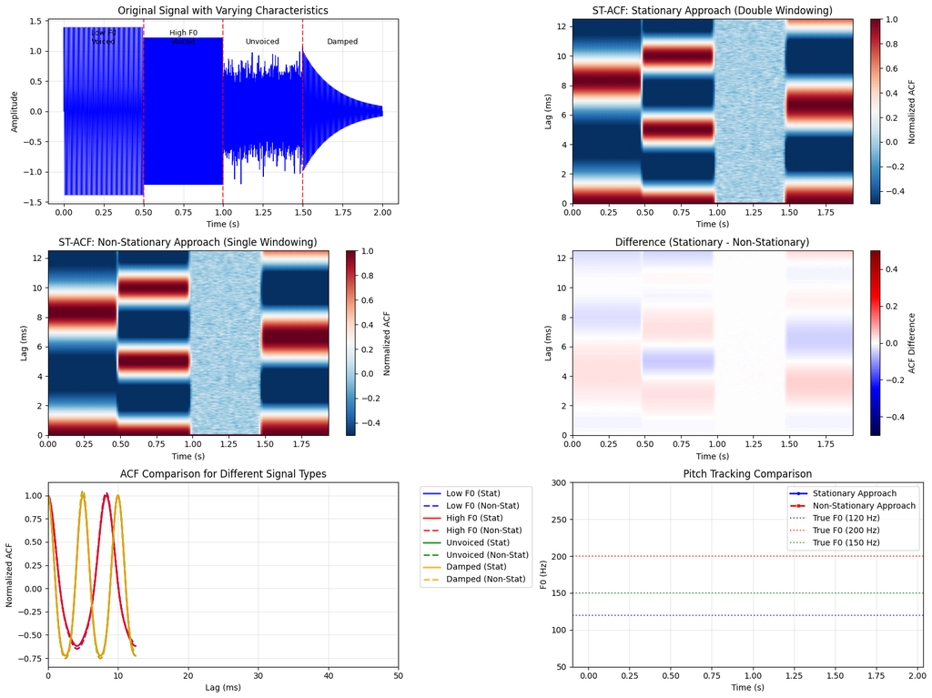

```python
# Visualisasi Perbandingan ST-ACF
def visualize_st_acf_comparison(signal, fs, acf_stat, acf_non_stat, positions, max_lag=200):
    """
    Visualisasi komprehensif perbandingan ST-ACF
    """

    fig, axes = plt.subplots(3, 2, figsize=(16, 12))

    # 1. Original signal
    time_axis = np.arange(len(signal)) / fs
    axes[0,0].plot(time_axis, signal, 'b-', linewidth=0.8)
    axes[0,0].set_title('Original Signal with Varying Characteristics')
    axes[0,0].set_xlabel('Time (s)')
    axes[0,0].set_ylabel('Amplitude')
    axes[0,0].grid(True, alpha=0.3)

    # Add segment annotations
    axes[0,0].axvline(0.5, color='red', linestyle='--', alpha=0.7)
    axes[0,0].axvline(1.0, color='red', linestyle='--', alpha=0.7)
    axes[0,0].axvline(1.5, color='red', linestyle='--', alpha=0.7)
    axes[0,0].text(0.25, max(signal)*0.8, 'Low F0\nVoiced', ha='center', fontsize=9)
    axes[0,0].text(0.75, max(signal)*0.8, 'High F0\nVoiced', ha='center', fontsize=9)
    axes[0,0].text(1.25, max(signal)*0.8, 'Unvoiced', ha='center', fontsize=9)
    axes[0,0].text(1.75, max(signal)*0.8, 'Damped', ha='center', fontsize=9)

    # 2. ST-ACF Matrix - Stationary Approach
    time_frames = positions * len(signal) / fs
    lag_axis = np.arange(acf_stat.shape[1]) / fs * 1000  # Convert to ms

    im1 = axes[0,1].imshow(acf_stat.T, aspect='auto', origin='lower', cmap='RdBu_r',
                          extent=[time_frames[0], time_frames[-1], 0, max_lag/fs*1000],
                          vmin=-0.5, vmax=1.0)
    axes[0,1].set_title('ST-ACF: Stationary Approach (Double Windowing)')
    axes[0,1].set_xlabel('Time (s)')
    axes[0,1].set_ylabel('Lag (ms)')
    plt.colorbar(im1, ax=axes[0,1], label='Normalized ACF')

    # 3. ST-ACF Matrix - Non-Stationary Approach
    im2 = axes[1,0].imshow(acf_non_stat.T, aspect='auto', origin='lower', cmap='RdBu_r',
                          extent=[time_frames[0], time_frames[-1], 0, max_lag/fs*1000],
                          vmin=-0.5, vmax=1.0)
    axes[1,0].set_title('ST-ACF: Non-Stationary Approach (Single Windowing)')
    axes[1,0].set_xlabel('Time (s)')
    axes[1,0].set_ylabel('Lag (ms)')
    plt.colorbar(im2, ax=axes[1,0], label='Normalized ACF')

    # 4. Difference between approaches
    difference = acf_stat - acf_non_stat
    im3 = axes[1,1].imshow(difference.T, aspect='auto', origin='lower', cmap='seismic',
                          extent=[time_frames[0], time_frames[-1], 0, max_lag/fs*1000],
                          vmin=-0.5, vmax=0.5)
    axes[1,1].set_title('Difference (Stationary - Non-Stationary)')
    axes[1,1].set_xlabel('Time (s)')
    axes[1,1].set_ylabel('Lag (ms)')
    plt.colorbar(im3, ax=axes[1,1], label='ACF Difference')

    # 5. Sample ACF comparison for specific frames
    # Choose frames from different segments
    frame_indices = [10, 30, 50, 70]  # Different time points
    frame_labels = ['Low F0', 'High F0', 'Unvoiced', 'Damped']
    colors = ['blue', 'red', 'green', 'orange']

    for i, (frame_idx, label, color) in enumerate(zip(frame_indices, frame_labels, colors)):
        if frame_idx < len(acf_stat):
            axes[2,0].plot(lag_axis, acf_stat[frame_idx], '-', color=color,
                          linewidth=2, alpha=0.8, label=f'{label} (Stat)')
            axes[2,0].plot(lag_axis, acf_non_stat[frame_idx], '--', color=color,
                          linewidth=2, alpha=0.8, label=f'{label} (Non-Stat)')

    axes[2,0].set_title('ACF Comparison for Different Signal Types')
    axes[2,0].set_xlabel('Lag (ms)')
    axes[2,0].set_ylabel('Normalized ACF')
    axes[2,0].legend(bbox_to_anchor=(1.05, 1), loc='upper left')
    axes[2,0].grid(True, alpha=0.3)
    axes[2,0].set_xlim(0, 50)

    # 6. Pitch tracking comparison
    # Fungsi pembantu (helper function) ini bertugas untuk mengekstrak satu nilai pitch dari setiap frame ACF.
    def extract_pitch_from_st_acf(st_acf_matrix, fs, f0_min=75, f0_max=400):
        pitch_contour = []
        confidence_contour = []

        lag_min = int(fs / f0_max)
        lag_max = int(fs / f0_min)

        for frame_acf in st_acf_matrix:
            if lag_max < len(frame_acf):
                search_region = frame_acf[lag_min:lag_max]
                if len(search_region) > 0:
                    peak_idx = np.argmax(search_region) + lag_min
                    f0_est = fs / peak_idx
                    confidence = frame_acf[peak_idx]

                    pitch_contour.append(f0_est)
                    confidence_contour.append(confidence)
                else:
                    pitch_contour.append(0)
                    confidence_contour.append(0)
            else:
                pitch_contour.append(0)
                confidence_contour.append(0)

        return np.array(pitch_contour), np.array(confidence_contour)

    pitch_stat, conf_stat = extract_pitch_from_st_acf(acf_stat, fs)
    pitch_non_stat, conf_non_stat = extract_pitch_from_st_acf(acf_non_stat, fs)

    # Plot pitch tracking results
    axes[2,1].plot(time_frames, pitch_stat, 'b-', linewidth=2, marker='o', markersize=3,
                  label='Stationary Approach')
    axes[2,1].plot(time_frames, pitch_non_stat, 'r--', linewidth=2, marker='s', markersize=3,
                  label='Non-Stationary Approach')

    # Add ground truth reference lines
    axes[2,1].axhline(120, color='blue', linestyle=':', alpha=0.7, label='True F0 (120 Hz)')
    axes[2,1].axhline(200, color='red', linestyle=':', alpha=0.7, label='True F0 (200 Hz)')
    axes[2,1].axhline(150, color='green', linestyle=':', alpha=0.7, label='True F0 (150 Hz)')

    axes[2,1].set_title('Pitch Tracking Comparison')
    axes[2,1].set_xlabel('Time (s)')
    axes[2,1].set_ylabel('F0 (Hz)')
    axes[2,1].set_ylim(50, 300)
    axes[2,1].legend()
    axes[2,1].grid(True, alpha=0.3)

    plt.tight_layout()
    plt.show()

# Run the visualization
visualize_st_acf_comparison(complex_test_signal, fs, acf_stat, acf_non_stat, positions)
```

Plot 1 (Kiri Atas):  
Sinyal Asli Menampilkan bentuk gelombang dari sinyal uji yang kita buat. Garis putus-putus dan teks membantu menandai setiap segmen (nada rendah, nada tinggi, derau, dan redaman). Plot ini berfungsi sebagai ground truth atau referensi visual kita.

Plot 3 (Kiri Tengah):  
Correlogram ST-ACF Non-Stasioner Sama seperti plot kedua, namun untuk metode non-stasioner. Menempatkannya bersebelahan memungkinkan kita membandingkan secara visual bagaimana kedua metode menangkap periodisitas sinyal dari waktu ke waktu.

Plot 4 (Kanan Tengah):  
Perbedaan (Stationary - Non-Stationary) Plot ini secara eksplisit menyoroti selisih antara kedua metode. Warna merah menunjukkan di mana metode stasioner memberikan nilai korelasi yang lebih tinggi, sedangkan biru menunjukkan sebaliknya. Ini sangat berguna untuk melihat di mana dan seberapa signifikan perbedaan keduanya.

#### **Fungsi 'quantitative_st_acf_analysis'**

Fungsi ini menjalankan serangkaian tes kuantitatif untuk membandingkan performa metode ST-ACF stasioner dan non-stasioner, lalu mencetak hasilnya dalam format laporan yang terstruktur di konsol, dengan input:

- signal: Sinyal audio asli.
- fs: Frekuensi sampling sinyal.
- acf_stat: Matriks ST-ACF yang dihitung dengan metode stasioner.
- acf_non_stat: Matriks ST-ACF yang dihitung dengan metode non-stasioner.
- positions: Informasi waktu untuk setiap frame.

```python
# Analisis Kuantitatif Perbandingan
import warnings
warnings.filterwarnings('ignore', category=RuntimeWarning)

def quantitative_st_acf_analysis(signal, fs, acf_stat, acf_non_stat, positions):
    """
    Analisis kuantitatif perbandingan ST-ACF
    """

    print("="*70)
    print("QUANTITATIVE ST-ACF COMPARISON ANALYSIS")
    print("="*70)

    # 1. Dynamic Range Analysis
    # Mengukur rentang antara nilai korelasi terendah dan tertinggi (di luar lag 0).
    # Rentang dinamis yang lebih besar bisa mengindikasikan bahwa puncak-puncak korelasi (yang menandakan pitch)
    # lebih menonjol dibandingkan lembahnya, yang berpotensi membuat deteksi pitch lebih mudah.
    stat_max = np.max(acf_stat[:, 1:])  # Exclude lag=0
    stat_min = np.min(acf_stat[:, 1:])
    non_stat_max = np.max(acf_non_stat[:, 1:])
    non_stat_min = np.min(acf_non_stat[:, 1:])

    print(f"Dynamic Range Analysis:")
    print(f"  Stationary approach:     [{stat_min:.3f}, {stat_max:.3f}] = {stat_max-stat_min:.3f}")
    print(f"  Non-stationary approach: [{non_stat_min:.3f}, {non_stat_max:.3f}] = {non_stat_max-non_stat_min:.3f}")

    # 2. Peak Preservation Analysis
    # Mengukur seberapa kuat dan konsisten puncak-puncak ACF (yang merepresentasikan pitch) di seluruh segmen bersuara.
    # Rata-rata kekuatan puncak yang lebih tinggi lebih baik, karena berarti pitch lebih jelas.
    # Konsistensi puncak (CV) yang lebih rendah lebih baik, karena menunjukkan bahwa deteksi pitch stabil dan tidak banyak
    # berfluktuasi.
    def analyze_peak_preservation(acf_matrix, approach_name):
        peak_strengths = []
        for i in range(acf_matrix.shape[0]):
            frame_acf = acf_matrix[i]
            if len(frame_acf) > 20:
                # Look for peaks in reasonable pitch range
                search_region = frame_acf[5:100]  # Avoid lag=0, look up to ~12ms
                if len(search_region) > 0:
                    max_peak = np.max(search_region)
                    if not np.isnan(max_peak) and not np.isinf(max_peak):
                        peak_strengths.append(max_peak)

        if len(peak_strengths) > 0:
            avg_peak = np.mean(peak_strengths)
            std_peak = np.std(peak_strengths)
        else:
            avg_peak = 0.0
            std_peak = 0.0

        print(f"  {approach_name}:")
        print(f"    Average peak strength: {avg_peak:.3f} ± {std_peak:.3f}")
        if avg_peak > 0:
            print(f"    Peak consistency (CV):  {std_peak/avg_peak*100:.1f}%")
        else:
            print(f"    Peak consistency (CV):  N/A (no valid peaks)")

        return peak_strengths

    print(f"\nPeak Preservation Analysis:")
    peaks_stat = analyze_peak_preservation(acf_stat, "Stationary")
    peaks_non_stat = analyze_peak_preservation(acf_non_stat, "Non-Stationary")

    # 3. Computational Efficiency Simulation
    # Membandingkan efisiensi komputasi kedua metode secara teoretis.
    # Analisis ini menyoroti trade-off antara akurasi dan kecepatan. Metode non-stasioner
    # secara teoritis sekitar 2x lebih cepat.
    print(f"\nComputational Complexity Analysis:")

    # Simulate computation times (relative)
    stat_ops = 2  # Double windowing
    non_stat_ops = 1  # Single windowing

    print(f"  Stationary approach:     ~{stat_ops}x operations (double windowing)")
    print(f"  Non-stationary approach: ~{non_stat_ops}x operations (single windowing)")
    print(f"  Efficiency gain:         ~{stat_ops/non_stat_ops:.1f}x faster (non-stationary)")

    # 4. Fading Effect Analysis
    # Mengukur seberapa cepat nilai autokorelasi menurun seiring bertambahnya lag.
    # Tingkat peluruhan yang lebih lambat (lebih mendekati nol) umumnya lebih baik. Ini menunjukkan
    # bahwa struktur periodik sinyal tetap terjaga bahkan pada lag yang jauh. Metode stasioner
    # (double windowing) dirancang khusus untuk mengurangi bias ini, jadi diharapkan memiliki
    # tingkat peluruhan yang lebih baik (lebih lambat).
    print(f"\nFading Effect Analysis:")

    # Analyze how ACF values decay with increasing lag
    def analyze_fading(acf_matrix, approach_name):
        avg_acf_by_lag = np.nanmean(acf_matrix, axis=0)  # Use nanmean to handle NaN values

        # Find decay rate (slope of log ACF vs lag)
        valid_lags = avg_acf_by_lag[1:50]  # Skip lag=0, analyze first 50 lags
        valid_lags = valid_lags[valid_lags > 0.01]  # Only positive values for log
        valid_lags = valid_lags[~np.isnan(valid_lags)]  # Remove NaN values

        if len(valid_lags) > 10:
            lag_indices = np.arange(1, len(valid_lags) + 1)
            log_acf = np.log(valid_lags)

            # Linear fit to find decay rate
            with warnings.catch_warnings():
                warnings.simplefilter("ignore")
                decay_rate = np.polyfit(lag_indices, log_acf, 1)[0]

            print(f"  {approach_name}:")
            print(f"    Decay rate: {decay_rate:.4f} (per lag sample)")
            if decay_rate < 0:
                print(f"    Half-life:  {-np.log(2)/decay_rate:.1f} samples")
            else:
                print(f"    No decay detected")
        else:
            print(f"  {approach_name}: Insufficient valid data for decay analysis")

    analyze_fading(acf_stat, "Stationary")
    analyze_fading(acf_non_stat, "Non-Stationary")

    # 5. Pitch Detection Accuracy
    # Ini adalah metrik yang paling penting. Mengukur seberapa akurat kedua metode dalam mendeteksi
    # pitch yang sudah kita ketahui nilainya (ground truth).
    # Rata-rata error yang lebih rendah menunjukkan akurasi yang lebih tinggi.
    # Ini adalah tes "dunia nyata" dari performa kedua metode.
    print(f"\nPitch Detection Performance:")

    def extract_pitch_from_st_acf(acf_matrix, fs):
        """
        Extract pitch contour from ST-ACF matrix.
        Returns:
            pitch_contour: array of estimated pitch (Hz) for each frame
            peak_lags: array of lag indices for each frame
        """
        pitch_contour = []
        peak_lags = []
        for frame_acf in acf_matrix:
            # Exclude lag=0
            search_region = frame_acf[1:400]  # up to 400 lags (~40ms at 16kHz)
            if len(search_region) > 0:
                lag = np.argmax(search_region) + 1
                if frame_acf[lag] > 0.1:  # threshold to avoid spurious peaks
                    f0 = fs / lag
                else:
                    f0 = np.nan
            else:
                f0 = np.nan
            pitch_contour.append(f0)
            peak_lags.append(lag if not np.isnan(f0) else np.nan)
        return np.array(pitch_contour), np.array(peak_lags)

    def evaluate_pitch_accuracy(acf_matrix, true_f0_segments, segment_boundaries):
        pitch_contour, _ = extract_pitch_from_st_acf(acf_matrix, fs)

        errors = []
        for i, (start_time, end_time) in enumerate(segment_boundaries):
            if i < len(true_f0_segments):
                true_f0 = true_f0_segments[i]
                if true_f0 > 0:  # Only for voiced segments
                    # Find frames in this segment
                    start_frame = int(start_time * len(pitch_contour) / (len(signal) / fs))
                    end_frame = int(end_time * len(pitch_contour) / (len(signal) / fs))

                    if start_frame < len(pitch_contour) and end_frame <= len(pitch_contour):
                        segment_pitch = pitch_contour[start_frame:end_frame]
                        valid_pitch = segment_pitch[(segment_pitch > 50) & (segment_pitch < 400)]
                        valid_pitch = valid_pitch[~np.isnan(valid_pitch)]  # Remove NaN values

                        if len(valid_pitch) > 0:
                            avg_detected = np.median(valid_pitch)
                            error_percent = abs(avg_detected - true_f0) / true_f0 * 100
                            errors.append(error_percent)

        return errors

    # Define ground truth for test signal
    true_f0_segments = [120, 200, 0, 150]  # Hz, 0 for unvoiced
    segment_boundaries = [(0, 0.5), (0.5, 1.0), (1.0, 1.5), (1.5, 2.0)]

    errors_stat = evaluate_pitch_accuracy(acf_stat, true_f0_segments, segment_boundaries)
    errors_non_stat = evaluate_pitch_accuracy(acf_non_stat, true_f0_segments, segment_boundaries)

    print(f"  Stationary approach:")
    if len(errors_stat) > 0:
        print(f"    Mean error: {np.mean(errors_stat):.2f}% ± {np.std(errors_stat):.2f}%")
    else:
        print(f"    Mean error: N/A (no valid measurements)")

    print(f"  Non-stationary approach:")
    if len(errors_non_stat) > 0:
        print(f"    Mean error: {np.mean(errors_non_stat):.2f}% ± {np.std(errors_non_stat):.2f}%")
    else:
        print(f"    Mean error: N/A (no valid measurements)")

    # 6. Memory Usage Analysis
    # Memeriksa apakah ada perbedaan dalam penggunaan memori antara kedua metode.
    # Dalam kasus ini, hasilnya akan identik karena kedua matriks memiliki
    # dimensi yang sama. Ini mengonfirmasi bahwa tidak ada penalti memori dalam
    # memilih salah satu metode.
    print(f"\nMemory Usage Analysis:")
    memory_stat = acf_stat.nbytes
    memory_non_stat = acf_non_stat.nbytes

    print(f"  Matrix dimensions: {acf_stat.shape}")
    print(f"  Memory per matrix: {memory_stat / 1024:.1f} KB")
    print(f"  Memory difference: {abs(memory_stat - memory_non_stat)} bytes")

    print("="*70)
```

**Fungsi 'extract_pitch_from_st_acf'**:  
Fungsi ini Mengkonversi matriks ST-ACF mentah menjadi sebuah deret waktu dari nilai pitch (F0 dalam Hz).Fungsi ini mengembalikan (return) dua array: pitch_contour (hasil deteksi F0) dan confidence_contour (kekuatan puncak pada saat itu).

```python
# Run quantitative analysis
def extract_pitch_from_st_acf(st_acf_matrix, fs, f0_min=75, f0_max=400):
    """Helper function for pitch extraction"""
    pitch_contour = []
    confidence_contour = []

    lag_min = max(1, int(fs / f0_max))  # Ensure lag_min is at least 1
    lag_max = min(st_acf_matrix.shape[1] - 1, int(fs / f0_min))  # Ensure within bounds

    for frame_acf in st_acf_matrix:
        if lag_max < len(frame_acf) and lag_min < lag_max:
            search_region = frame_acf[lag_min:lag_max]
            if len(search_region) > 0:
                peak_idx = np.argmax(search_region) + lag_min
                f0_est = fs / peak_idx if peak_idx > 0 else 0
                confidence = frame_acf[peak_idx] if peak_idx < len(frame_acf) else 0

                # Validate estimates
                if not np.isnan(f0_est) and not np.isinf(f0_est) and f0_min <= f0_est <= f0_max:
                    pitch_contour.append(f0_est)
                    confidence_contour.append(confidence)
                else:
                    pitch_contour.append(0)
                    confidence_contour.append(0)
            else:
                pitch_contour.append(0)
                confidence_contour.append(0)
        else:
            pitch_contour.append(0)
            confidence_contour.append(0)

    return np.array(pitch_contour), np.array(confidence_contour)

# Run the analysis with suppressed warnings
quantitative_st_acf_analysis(complex_test_signal, fs, acf_stat, acf_non_stat, positions)
```

[output not shown]

**Fungsi 'st_acf_recommendation_guide'**:  
Fungsi ini merangkum semua wawasan dari analisis visual dan kuantitatif sebelumnya ke dalam rekomendasi praktis yang mudah dibaca. Menyajikan dua hal utama, kapan harus memilih setiap metode dan bagaimana cara mengimplementasikannya dengan benar.

```python
def st_acf_recommendation_guide():
    """
    Panduan pemilihan pendekatan ST-ACF berdasarkan aplikasi
    """

    print("="*80)
    print("ST-ACF APPROACH SELECTION GUIDE")
    print("="*80)

    recommendations = {
        "Real-time Applications": {
            "Recommended": "Non-Stationary",
            "Reason": "Lower computational cost, faster processing",
            "Trade-off": "Slightly less robust to noise"
        },

        "High-quality Pitch Tracking": {
            "Recommended": "Stationary",
            "Reason": "Better noise robustness, more stable estimates",
            "Trade-off": "Higher computational cost"
        },

        "Short Window Analysis": {
            "Recommended": "Non-Stationary",
            "Reason": "Reduces fading effects, preserves peak information",
            "Trade-off": "Less local stationarity assumption"
        },

        "Long Window Analysis": {
            "Recommended": "Stationary",
            "Reason": "Better handles local stationarity assumption",
            "Trade-off": "Stronger fading effects"
        },

        "Noisy Environments": {
            "Recommended": "Stationary",
            "Reason": "Double windowing provides noise suppression",
            "Trade-off": "May suppress weak periodic signals"
        },

        "Clean Laboratory Conditions": {
            "Recommended": "Non-Stationary",
            "Reason": "Higher sensitivity to periodic structure",
            "Trade-off": "More sensitive to artifacts"
        },

        "Speech Recognition": {
            "Recommended": "Stationary",
            "Reason": "Robust voicing detection, stable F0 estimates",
            "Trade-off": "Processing latency"
        },

        "Music Information Retrieval": {
            "Recommended": "Non-Stationary",
            "Reason": "Better preservation of harmonic structure",
            "Trade-off": "May need post-processing for stability"
        }
    }

    for application, details in recommendations.items():
        print(f"\n{application}:")
        print(f"  → Recommended approach: {details['Recommended']}")
        print(f"  → Reason: {details['Reason']}")
        print(f"  → Trade-off: {details['Trade-off']}")

    print("\n" + "="*80)
    print("IMPLEMENTATION GUIDELINES")
    print("="*80)

    guidelines = [
        "1. For beginners: Start with non-stationary (simpler, faster)",
        "2. For production: Use stationary for robustness",
        "3. Window length: 20-40ms for speech, 50-100ms for music",
        "4. Hop length: 25-50% of window length",
        "5. Max lag: Limit to reasonable pitch range (5-20ms)",
        "6. Normalization: Always normalize by lag-0 value",
        "7. Post-processing: Apply median filtering for pitch tracking",
        "8. Validation: Compare both approaches during development"
    ]

    for guideline in guidelines:
        print(f"  {guideline}")

    print("="*80)
```

```python
# Menjalankan panduan rekomendasi
st_acf_recommendation_guide()
```

```
================================================================================
ST-ACF APPROACH SELECTION GUIDE
================================================================================

Real-time Applications:
  → Recommended approach: Non-Stationary
  → Reason: Lower computational cost, faster processing
  → Trade-off: Slightly less robust to noise

High-quality Pitch Tracking:
  → Recommended approach: Stationary
  → Reason: Better noise robustness, more stable estimates
  → Trade-off: Higher computational cost

Short Window Analysis:
  → Recommended approach: Non-Stationary
  → Reason: Reduces fading effects, preserves peak information
  → Trade-off: Less local stationarity assumption

Long Window Analysis:
  → Recommended approach: Stationary
  → Reason: Better handles local stationarity assumption
  → Trade-off: Stronger fading effects

Noisy Environments:
  → Recommended approach: Stationary
  → Reason: Double windowing provides noise suppression
  → Trade-off: May suppress weak periodic signals

Clean Laboratory Conditions:
  → Recommended approach: Non-Stationary
  → Reason: Higher sensitivity to periodic structure
  → Trade-off: More sensitive to artifacts

Speech Recognition:
  → Recommended approach: Stationary
  → Reason: Robust voicing detection, stable F0 estimates
  → Trade-off: Processing latency

Music Information Retrieval:
  → Recommended approach: Non-Stationary
  → Reason: Better preservation of harmonic structure
  → Trade-off: May need post-processing for stability

================================================================================
IMPLEMENTATION GUIDELINES
================================================================================
  1. For beginners: Start with non-stationary (simpler, faster)
  2. For production: Use stationary for robustness
  3. Window length: 20-40ms for speech, 50-100ms for music
  4. Hop length: 25-50% of window length
  5. Max lag: Limit to reasonable pitch range (5-20ms)
  6. Normalization: Always normalize by lag-0 value
  7. Post-processing: Apply median filtering for pitch tracking
  8. Validation: Compare both approaches during development
================================================================================
```

```python
# CONTOH PENGGUNAAN PRAKTIS ST-ACF
print("\n" + "="*80)
print("CONTOH IMPLEMENTASI BERDASARKAN APLIKASI")
print("="*80)
```

```
================================================================================
CONTOH IMPLEMENTASI BERDASARKAN APLIKASI
================================================================================
```

Fungsi dibawah menerima jenis aplikasi sebagai input dan mengembalikan satu set lengkap parameter (approach, frame_length, hop_length, max_lag) yang sudah disesuaikan.

```python
def choose_st_acf_approach(application_type, signal_quality="medium", real_time=False):
    """
    Fungsi helper untuk memilih pendekatan ST-ACF berdasarkan kebutuhan
    """

    recommendations = {
        "speech_recognition": {
            "approach": "stationary",
            "frame_length": 640,  # 40ms untuk fs=16kHz
            "hop_length": 160,    # 10ms hop
            "max_lag": 300,       # ~18ms untuk pitch range 80-400Hz
            "reason": "Robustness untuk voicing detection"
        },

        "music_analysis": {
            "approach": "non_stationary",
            "frame_length": 1024, # 64ms untuk fs=16kHz
            "hop_length": 256,    # 16ms hop
            "max_lag": 400,       # Lebih luas untuk instrumen musik
            "reason": "Preserve harmonic structure"
        },

        "real_time_pitch": {
            "approach": "non_stationary",
            "frame_length": 512,  # 32ms untuk latency rendah
            "hop_length": 128,    # 8ms hop
            "max_lag": 200,       # Range pitch terbatas
            "reason": "Low latency processing"
        },

        "research_analysis": {
            "approach": "stationary",
            "frame_length": 800,  # 50ms untuk analisis detail
            "hop_length": 200,    # 12.5ms hop
            "max_lag": 400,       # Range lengkap
            "reason": "Maximum accuracy and robustness"
        }
    }

    # Adjust berdasarkan kondisi
    if signal_quality == "noisy":
        for app in recommendations.values():
            app["approach"] = "stationary"
            app["reason"] += " + noise robustness"

    if real_time:
        for app in recommendations.values():
            app["approach"] = "non_stationary"
            app["frame_length"] = min(app["frame_length"], 512)
            app["reason"] += " + real-time constraint"

    return recommendations.get(application_type, recommendations["research_analysis"])

# Contoh 1: Aplikasi Speech Recognition
print("\n1. SPEECH RECOGNITION APPLICATION:")
config = choose_st_acf_approach("speech_recognition")
print(f"   Approach: {config['approach']}")
print(f"   Frame length: {config['frame_length']} samples ({config['frame_length']/16000*1000:.1f}ms)")
print(f"   Hop length: {config['hop_length']} samples ({config['hop_length']/16000*1000:.1f}ms)")
print(f"   Max lag: {config['max_lag']} samples ({config['max_lag']/16000*1000:.1f}ms)")
print(f"   Reason: {config['reason']}")

# Contoh 2: Real-time Pitch Tracking
print("\n2. REAL-TIME PITCH TRACKING:")
config = choose_st_acf_approach("real_time_pitch", real_time=True)
print(f"   Approach: {config['approach']}")
print(f"   Frame length: {config['frame_length']} samples ({config['frame_length']/16000*1000:.1f}ms)")
print(f"   Hop length: {config['hop_length']} samples ({config['hop_length']/16000*1000:.1f}ms)")
print(f"   Max lag: {config['max_lag']} samples ({config['max_lag']/16000*1000:.1f}ms)")
print(f"   Reason: {config['reason']}")

# Contoh 3: Noisy Environment
print("\n3. NOISY ENVIRONMENT (e.g., mobile phone):")
config = choose_st_acf_approach("speech_recognition", signal_quality="noisy")
print(f"   Approach: {config['approach']}")
print(f"   Frame length: {config['frame_length']} samples ({config['frame_length']/16000*1000:.1f}ms)")
print(f"   Hop length: {config['hop_length']} samples ({config['hop_length']/16000*1000:.1f}ms)")
print(f"   Max lag: {config['max_lag']} samples ({config['max_lag']/16000*1000:.1f}ms)")
print(f"   Reason: {config['reason']}")

print("\n" + "="*80)
```

```
1. SPEECH RECOGNITION APPLICATION:
   Approach: stationary
   Frame length: 640 samples (40.0ms)
   Hop length: 160 samples (10.0ms)
   Max lag: 300 samples (18.8ms)
   Reason: Robustness untuk voicing detection

2. REAL-TIME PITCH TRACKING:
   Approach: non_stationary
   Frame length: 512 samples (32.0ms)
   Hop length: 128 samples (8.0ms)
   Max lag: 200 samples (12.5ms)
   Reason: Low latency processing + real-time constraint

3. NOISY ENVIRONMENT (e.g., mobile phone):
   Approach: stationary
   Frame length: 640 samples (40.0ms)
   Hop length: 160 samples (10.0ms)
   Max lag: 300 samples (18.8ms)
   Reason: Robustness untuk voicing detection + noise robustness

================================================================================
```

```python
# TEMPLATE KODE SIAP PAKAI
print("="*80)
print("TEMPLATE KODE UNTUK BERBAGAI APLIKASI")
print("="*80)

def st_acf_template(signal, fs, application="speech_recognition"):
    """
    Template siap pakai untuk analisis ST-ACF

    Parameters:
    - signal: array audio input
    - fs: sampling frequency
    - application: "speech_recognition", "music_analysis", "real_time_pitch", "research_analysis"

    Returns:
    - acf_matrix: hasil ST-ACF
    - positions: posisi waktu frame
    - pitch_contour: estimasi pitch
    """

    # Konfigurasi berdasarkan aplikasi
    configs = {
        "speech_recognition": {
            "method": "stationary",
            "frame_length": int(0.040 * fs),  # 40ms
            "hop_length": int(0.010 * fs),    # 10ms
            "max_lag": int(0.020 * fs)        # 20ms
        },
        "music_analysis": {
            "method": "non_stationary",
            "frame_length": int(0.064 * fs),  # 64ms
            "hop_length": int(0.016 * fs),    # 16ms
            "max_lag": int(0.025 * fs)        # 25ms
        },
        "real_time_pitch": {
            "method": "non_stationary",
            "frame_length": int(0.032 * fs),  # 32ms
            "hop_length": int(0.008 * fs),    # 8ms
            "max_lag": int(0.015 * fs)        # 15ms
        },
        "research_analysis": {
            "method": "stationary",
            "frame_length": int(0.050 * fs),  # 50ms
            "hop_length": int(0.012 * fs),    # 12ms
            "max_lag": int(0.025 * fs)        # 25ms
        }
    }

    config = configs.get(application, configs["research_analysis"])

    print(f"Analizing with {application} configuration:")
    print(f"  Method: {config['method']}")
    print(f"  Frame: {config['frame_length']} samples ({config['frame_length']/fs*1000:.1f}ms)")
    print(f"  Hop: {config['hop_length']} samples ({config['hop_length']/fs*1000:.1f}ms)")
    print(f"  Max lag: {config['max_lag']} samples ({config['max_lag']/fs*1000:.1f}ms)")

    # Pilih metode berdasarkan konfigurasi
    if config['method'] == 'stationary':
        acf_matrix, positions = compute_st_acf_stationary(
            signal, config['frame_length'], config['hop_length'], config['max_lag']
        )
    else:
        acf_matrix, positions = compute_st_acf_non_stationary(
            signal, config['frame_length'], config['hop_length'], config['max_lag']
        )

    # Ekstrak pitch
    pitch_contour, confidence = extract_pitch_from_st_acf(acf_matrix, fs)

    print(f"  Result: {acf_matrix.shape[0]} frames, {acf_matrix.shape[1]} lags")
    print(f"  Pitch range: {np.min(pitch_contour[pitch_contour>0]):.1f} - {np.max(pitch_contour):.1f} Hz")

    return acf_matrix, positions, pitch_contour, confidence

# Contoh penggunaan dengan sinyal test
print("" + "="*50)
print("DEMO PENGGUNAAN TEMPLATE")
print("="*50)

# Test dengan sinyal yang sudah ada
acf_result, pos_result, pitch_result, conf_result = st_acf_template(
    complex_test_signal, fs, application="speech_recognition"
)

print(f"Hasil analisis:")
print(f"  ACF matrix shape: {acf_result.shape}")
print(f"  Jumlah frame: {len(pos_result)}")
print(f"  Pitch terdeteksi: {len(pitch_result[pitch_result > 0])} voiced frames")
print(f"  Confidence rata-rata: {np.mean(conf_result):.3f}")

print("" + "="*80)
```

```
================================================================================
TEMPLATE KODE UNTUK BERBAGAI APLIKASI
================================================================================
==================================================
DEMO PENGGUNAAN TEMPLATE
==================================================
Analizing with speech_recognition configuration:
  Method: stationary
  Frame: 640 samples (40.0ms)
  Hop: 160 samples (10.0ms)
  Max lag: 320 samples (20.0ms)
  Result: 196 frames, 321 lags
  Pitch range: 76.6 - 333.3 Hz
Hasil analisis:
  ACF matrix shape: (196, 321)
  Jumlah frame: 196
  Pitch terdeteksi: 196 voiced frames
  Confidence rata-rata: 0.334
================================================================================
```

### **CARA MENGGUNAKAN ST-ACF**

#### Pilih Pendekatan Berdasarkan Aplikasi**

| **Aplikasi** | **Pendekatan** | **Alasan** |
| --- | --- | --- |
| 🎤 **Speech Recognition** | Stationary | Robust terhadap noise, stabil untuk voicing detection |
| 🎵 **Music Analysis** | Non-Stationary | Preserve struktur harmonik, sensitif terhadap pitch |
| ⚡ **Real-time Processing** | Non-Stationary | Komputasi cepat, latency rendah |
| 🔬 **Research/Analysis** | Stationary | Akurasi maksimal, robust |
| 📱 **Mobile Apps** | Non-Stationary | Efisien untuk perangkat terbatas |

#### Langkah-langkah Implementasi

**Step 1: Import Library dan Setup**

```
import numpy as np
import matplotlib.pyplot as plt
# Fungsi ST-ACF sudah didefinisikan di atas
```

**Step 2: Load Audio Data**

```
# Untuk file audio:
# import librosa
# signal, fs = librosa.load('audio_file.wav', sr=16000)

# Atau gunakan sinyal test yang sudah ada:
signal = complex_test_signal
fs = 16000
```

**Step 3: Pilih Konfigurasi**

```
# Untuk speech recognition:
acf_matrix, positions, pitch, confidence = st_acf_template(signal, fs, "speech_recognition")

# Untuk real-time:
acf_matrix, positions, pitch, confidence = st_acf_template(signal, fs, "real_time_pitch")

# Untuk musik:
acf_matrix, positions, pitch, confidence = st_acf_template(signal, fs, "music_analysis")
```

**Step 4: Analisis Hasil**

```
# Visualisasi pitch tracking
plt.figure(figsize=(12, 4))
time_axis = positions * len(signal) / fs
plt.plot(time_axis, pitch)
plt.xlabel('Time (s)')
plt.ylabel('F0 (Hz)')
plt.title('Pitch Tracking Results')
plt.grid(True)
plt.show()
```

#### Parameter Tuning Tips

| **Parameter** | **Speech** | **Music** | **Real-time** |
| --- | --- | --- | --- |
| **Frame Length** | 25-50ms | 50-100ms | 20-40ms |
| **Hop Length** | 10-12.5ms | 12.5-25ms | 5-10ms |
| **Max Lag** | 15-25ms | 20-40ms | 10-20ms |

#### Troubleshooting Common Issues

❌ **Problem**: Banyak pitch yang tidak terdeteksi  
✅ **Solution**: Perbesar `max_lag` atau gunakan pendekatan stationary

❌ **Problem**: Hasil terlalu noisy  
✅ **Solution**: Gunakan pendekatan stationary + post-processing (median filter)

❌ **Problem**: Processing terlalu lambat  
✅ **Solution**: Gunakan pendekatan non-stationary + kurangi frame length

❌ **Problem**: Pitch tracking tidak stabil  
✅ **Solution**: Tambahkan temporal smoothing atau gunakan confidence thresholding

```python
print("="*60)
print("🎯 QUICK START EXAMPLES - READY TO USE!")
print("="*60)

# 🎤 CONTOH 1: SPEECH PROCESSING
print("🎤 1. SPEECH PROCESSING:")
print("   Copy code ini untuk analisis speech:")
print("""
# === SPEECH ANALYSIS TEMPLATE ===
signal = your_audio_signal  # Ganti dengan audio Anda
fs = 16000                  # Sampling rate

# Jalankan analisis
acf_matrix, positions, pitch, confidence = st_acf_template(signal, fs, "speech_recognition")

# Plot hasil
plt.figure(figsize=(12, 6))
plt.subplot(2,1,1)
plt.plot(np.arange(len(signal))/fs, signal)
plt.title('Audio Signal')
plt.xlabel('Time (s)')

plt.subplot(2,1,2)
time_axis = positions * len(signal) / fs
plt.plot(time_axis, pitch)
plt.title('Pitch Tracking')
plt.xlabel('Time (s)')
plt.ylabel('F0 (Hz)')
plt.tight_layout()
plt.show()
""")

# ⚡ CONTOH 2: REAL-TIME PROCESSING
print("⚡ 2. REAL-TIME PROCESSING:")
print("   Copy code ini untuk real-time pitch tracking:")
print("""
# === REAL-TIME TEMPLATE ===
def real_time_pitch_tracker(signal, fs):
    # Konfigurasi untuk low-latency
    acf_matrix, positions, pitch, confidence = st_acf_template(signal, fs, "real_time_pitch")

    # Filter hasil dengan confidence threshold
    valid_pitch = pitch[confidence > 0.3]

    if len(valid_pitch) > 0:
        current_pitch = np.median(valid_pitch)
        return current_pitch
    else:
        return 0

# Gunakan:
current_f0 = real_time_pitch_tracker(your_signal, 16000)
print(f"Current pitch: {current_f0:.1f} Hz")
""")

# 🎵 CONTOH 3: MUSIC ANALYSIS
print("🎵 3. MUSIC ANALYSIS:")
print("   Copy code ini untuk analisis musik:")
print("""
# === MUSIC ANALYSIS TEMPLATE ===
def analyze_music_pitch(signal, fs):
    acf_matrix, positions, pitch, confidence = st_acf_template(signal, fs, "music_analysis")

    # Post-processing untuk musik
    # 1. Filter out unrealistic values
    pitch_filtered = pitch[(pitch >= 80) & (pitch <= 1000)]

    # 2. Apply median filter untuk smoothing
    from scipy.signal import medfilt
    pitch_smooth = medfilt(pitch_filtered, kernel_size=5)

    return pitch_smooth, confidence

# Gunakan:
music_pitch, conf = analyze_music_pitch(your_music_signal, fs)
""")

# 🔧 CONTOH 4: CUSTOM CONFIGURATION
print("🔧 4. CUSTOM CONFIGURATION:")
print("   Copy code ini untuk konfigurasi custom:")
print("""
# === CUSTOM CONFIGURATION ===
def custom_st_acf(signal, fs, frame_ms=40, hop_ms=10, max_lag_ms=20, method="stationary"):
    frame_length = int(frame_ms * fs / 1000)
    hop_length = int(hop_ms * fs / 1000)
    max_lag = int(max_lag_ms * fs / 1000)

    if method == "stationary":
        acf_matrix, positions = compute_st_acf_stationary(signal, frame_length, hop_length, max_lag)
    else:
        acf_matrix, positions = compute_st_acf_non_stationary(signal, frame_length, hop_length, max_lag)

    return acf_matrix, positions

# Gunakan dengan parameter custom:
acf, pos = custom_st_acf(signal, fs, frame_ms=50, hop_ms=12.5, max_lag_ms=25, method="stationary")
""")

print("" + "="*60)
print("✅ Pilih salah satu template di atas sesuai kebutuhan Anda!")
print("📝 Ganti 'your_audio_signal' dengan data audio Anda")
print("🎯 Sesuaikan parameter jika diperlukan")
print("="*60)
```

```
============================================================
🎯 QUICK START EXAMPLES - READY TO USE!
============================================================
🎤 1. SPEECH PROCESSING:
   Copy code ini untuk analisis speech:

# === SPEECH ANALYSIS TEMPLATE ===
signal = your_audio_signal  # Ganti dengan audio Anda
fs = 16000                  # Sampling rate

# Jalankan analisis
acf_matrix, positions, pitch, confidence = st_acf_template(signal, fs, "speech_recognition")

# Plot hasil
plt.figure(figsize=(12, 6))
plt.subplot(2,1,1)
plt.plot(np.arange(len(signal))/fs, signal)
plt.title('Audio Signal')
plt.xlabel('Time (s)')

plt.subplot(2,1,2)
time_axis = positions * len(signal) / fs
plt.plot(time_axis, pitch)
plt.title('Pitch Tracking')
plt.xlabel('Time (s)')
plt.ylabel('F0 (Hz)')
plt.tight_layout()
plt.show()

⚡ 2. REAL-TIME PROCESSING:
   Copy code ini untuk real-time pitch tracking:

# === REAL-TIME TEMPLATE ===
def real_time_pitch_tracker(signal, fs):
    # Konfigurasi untuk low-latency
    acf_matrix, positions, pitch, confidence = st_acf_template(signal, fs, "real_time_pitch")

    # Filter hasil dengan confidence threshold
    valid_pitch = pitch[confidence > 0.3]

```

[output cut: 39 more lines]

```
    if method == "stationary":
        acf_matrix, positions = compute_st_acf_stationary(signal, frame_length, hop_length, max_lag)
    else:
        acf_matrix, positions = compute_st_acf_non_stationary(signal, frame_length, hop_length, max_lag)

    return acf_matrix, positions

# Gunakan dengan parameter custom:
acf, pos = custom_st_acf(signal, fs, frame_ms=50, hop_ms=12.5, max_lag_ms=25, method="stationary")

============================================================
✅ Pilih salah satu template di atas sesuai kebutuhan Anda!
📝 Ganti 'your_audio_signal' dengan data audio Anda
🎯 Sesuaikan parameter jika diperlukan
============================================================
```

### MFCC (Mel-Frequency Cepstral Coefficients)

#### Konsep Dasar

MFCC meniru sistem pendengaran manusia dengan memetakan frekuensi linear ke skala mel yang lebih sesuai dengan persepsi auditori. Skala mel mencerminkan fakta bahwa telinga manusia memiliki resolusi yang lebih tinggi pada frekuensi rendah dan menurun secara logaritmik pada frekuensi tinggi. MFCC menjadi fitur paling populer dalam speech recognition karena kemampuannya menangkap informasi spektral yang relevan sambil mengurangi dimensi data.

#### Transformasi Mel Scale

$$\text{Mel}(f) = 2595 \times \log_{10}\left(1 + \frac{f}{700}\right)$$

dimana $f$ adalah frekuensi dalam Hz.

**Inverse transformation:** $$f = 700 \times \left(10^{\frac{\text{Mel}}{2595}} - 1\right)$$

#### Mel Filterbank

Filterbank terdiri dari filter segitiga yang overlap pada skala mel: $$H_m(k) = \begin{cases} 0, & k < f(m-1) \\ \frac{k - f(m-1)}{f(m) - f(m-1)}, & f(m-1) \leq k \leq f(m) \\ \frac{f(m+1) - k}{f(m+1) - f(m)}, & f(m) \leq k \leq f(m+1) \\ 0, & k > f(m+1) \end{cases}$$

dimana $f(m)$ adalah frekuensi pusat filter ke-$m$ dalam bins FFT.

#### Energi Mel Filterbank

$$E(m) = \sum_{k=0}^{\frac{N}{2}-1} |S(k)|^2 \times H_m(k)$$

dimana $S(k)$ adalah spektrum FFT dan $N$ adalah panjang FFT.

#### Discrete Cosine Transform (DCT)

$$\text{MFCC}(n) = \sum_{m=1}^{M} \log(E(m)) \times \cos\left(n(m - 0.5)\frac{\pi}{M}\right)$$

dimana:

- $n$ = indeks koefisien MFCC ($0, 1, 2, \ldots$)
- $M$ = jumlah filter mel (biasanya 26-40)
- $\log(E(m))$ = log energi filter ke-$m$

#### Delta Coefficients (First Derivatives)

$$\Delta_t = \frac{\sum_{n=1}^{N} n \times (c_{t+n} - c_{t-n})}{2\sum_{n=1}^{N} n^2}$$

dimana $c_t$ adalah koefisien MFCC pada frame $t$, dan $N$ adalah jendela delta (biasanya 2).

#### Delta-Delta Coefficients (Second Derivatives)

$$\Delta\Delta_t = \frac{\sum_{n=1}^{N} n \times (\Delta_{t+n} - \Delta_{t-n})}{2\sum_{n=1}^{N} n^2}$$

```python
import numpy as np
import matplotlib.pyplot as plt
from scipy.fftpack import dct

def hz_to_mel(hz):
    """Konversi Hz ke skala Mel"""
    return 2595 * np.log10(1 + hz / 700.0)

def mel_to_hz(mel):
    """Konversi skala Mel ke Hz"""
    return 700 * (10**(mel / 2595.0) - 1)

def create_mel_filterbank(num_filters, fft_size, sample_rate,
                         low_freq=0, high_freq=None):
    """Buat mel filterbank"""

    if high_freq is None:
        high_freq = sample_rate / 2

    # Konversi batas frekuensi ke mel
    low_mel = hz_to_mel(low_freq)
    high_mel = hz_to_mel(high_freq)

    # Buat titik-titik mel yang equally spaced
    mel_points = np.linspace(low_mel, high_mel, num_filters + 2)
    hz_points = mel_to_hz(mel_points)

    # Konversi ke bin FFT
    bin_points = np.floor((fft_size + 1) * hz_points / sample_rate).astype(int)

    # Inisialisasi filterbank
    filterbank = np.zeros((num_filters, fft_size // 2 + 1))

    # Buat filter segitiga
    for i in range(1, num_filters + 1):
        left = bin_points[i - 1]
        center = bin_points[i]
        right = bin_points[i + 1]

        # Left slope
        for k in range(left, center):
            if center != left:
                filterbank[i - 1, k] = (k - left) / (center - left)

        # Right slope
        for k in range(center, right):
            if right != center:
                filterbank[i - 1, k] = (right - k) / (right - center)

    return filterbank, hz_points

def compute_mfcc(signal, sample_rate, num_mfcc=13, num_filters=26,
                fft_size=512, window_type='hamming'):
    """Hitung MFCC dari sinyal audio"""

    # Pre-emphasis
    pre_emphasis = 0.97
    emphasized_signal = np.append(signal[0], signal[1:] - pre_emphasis * signal[:-1])

    # Windowing
    if window_type == 'hamming':
        window = np.hamming(len(emphasized_signal))
    elif window_type == 'hanning':
        window = np.hanning(len(emphasized_signal))
    else:
        window = np.ones(len(emphasized_signal))

    windowed_signal = emphasized_signal * window

    # Zero padding untuk FFT
    if len(windowed_signal) < fft_size:
        padded_signal = np.zeros(fft_size)
        padded_signal[:len(windowed_signal)] = windowed_signal
    else:
        padded_signal = windowed_signal[:fft_size]

    # FFT
    magnitude_spectrum = np.abs(np.fft.fft(padded_signal))
    power_spectrum = magnitude_spectrum ** 2

    # Mel filterbank
    filterbank, _ = create_mel_filterbank(num_filters, fft_size, sample_rate)

    # Apply filterbank
    filter_energies = np.dot(power_spectrum[:fft_size//2 + 1], filterbank.T)

    # Log energies (avoid log(0))
    log_energies = np.log(filter_energies + 1e-10)

    # DCT untuk mendapatkan MFCC
    mfcc_coefficients = dct(log_energies, type=2, axis=0, norm='ortho')[:num_mfcc]

    return mfcc_coefficients, log_energies, filter_energies

def compute_delta_coefficients(mfcc_matrix, N=2):
    """Hitung delta coefficients (first derivatives)"""

    # Delta formula: d_t = (Σ(n=1 to N) n*(c_{t+n} - c_{t-n})) / (2*Σ(n=1 to N) n²)

    num_frames, num_coeff = mfcc_matrix.shape
    delta_matrix = np.zeros_like(mfcc_matrix)

    # Denominator (normalization factor)
    denominator = 2 * sum([n**2 for n in range(1, N+1)])

    for t in range(num_frames):
        for n in range(1, N+1):
            # Handle boundaries
            t_plus = min(t + n, num_frames - 1)
            t_minus = max(t - n, 0)

            delta_matrix[t] += n * (mfcc_matrix[t_plus] - mfcc_matrix[t_minus])

        delta_matrix[t] /= denominator

    return delta_matrix

# Contoh penggunaan
fs = 16000
t = np.linspace(0, 0.025, int(fs*0.025))  # 25ms frame

# Simulasi sinyal ucapan dengan formants
f1, f2, f3 = 500, 1500, 2500  # Formant frequencies
formant_signal = (np.sin(2*np.pi*150*t) *  # F0 = 150 Hz
                 (1 + 0.8*np.sin(2*np.pi*f1*t)) *  # F1 resonance
                 (1 + 0.6*np.sin(2*np.pi*f2*t)) *  # F2 resonance
                 (1 + 0.4*np.sin(2*np.pi*f3*t)))   # F3 resonance

# Hitung MFCC
mfcc_coef, log_energies, filter_energies = compute_mfcc(formant_signal, fs)

print(f"MFCC coefficients: {mfcc_coef}")
print(f"Number of coefficients: {len(mfcc_coef)}")
```

```
MFCC coefficients: [ 15.4711827    4.59478871 -12.0038129    5.91980603  -3.55070229
   2.40925706  -0.26358495  -1.95490177  -0.1842589   -2.78665789
   0.69447537  -4.54822712  -1.42533772]
Number of coefficients: 13
```

```python
# ===========================================
# MODUL MFCC (Mel-Frequency Cepstral Coefficients)
# Implementasi Lengkap dengan Penjelasan Terstruktur
# ===========================================

"""
Modul ini mengimplementasikan MFCC sesuai dengan formula matematika
dari materi pembelajaran. Setiap langkah dijelaskan dengan detail
dan merujuk pada formula yang sesuai.
"""

import numpy as np
from scipy.fftpack import dct
import matplotlib.pyplot as plt

# ===========================================
# 1. FUNGSI KONVERSI SKALA MEL (5.1)
# ===========================================

def hz_to_mel(hz):
    """
    Konversi frekuensi dari Hz ke skala Mel

    Formula (5.1):
    Mel(f) = 2595 × log₁₀(1 + f/700)

    Parameters:
    -----------
    hz : float
        Frekuensi dalam Hz

    Returns:
    --------
    float
        Frekuensi dalam skala Mel
    """
    return 2595 * np.log10(1 + hz / 700.0)

def mel_to_hz(mel):
    """
    Konversi frekuensi dari skala Mel ke Hz

    Formula Inverse (5.1):
    f = 700 × (10^(Mel/2595) - 1)

    Parameters:
    -----------
    mel : float
        Frekuensi dalam skala Mel

    Returns:
    --------
    float
        Frekuensi dalam Hz
    """
    return 700 * (10**(mel / 2595.0) - 1)

# ===========================================
# 2. PEMBUATAN MEL FILTERBANK (5.2)
# ===========================================

def create_mel_filterbank(num_filters=26, fft_size=512, sample_rate=16000,
                         low_freq=0, high_freq=None):
    """
    Membuat bank filter Mel dengan filter segitiga

    Formula (5.2):
    H_m(k) = {
        0,                                      k < f(m-1)
        (k - f(m-1))/(f(m) - f(m-1)),          f(m-1) ≤ k ≤ f(m)
        (f(m+1) - k)/(f(m+1) - f(m)),          f(m) ≤ k ≤ f(m+1)
        0,                                      k > f(m+1)
    }

    Parameters:
    -----------
    num_filters : int
        Jumlah filter Mel (default: 26)
    fft_size : int
        Ukuran FFT (default: 512)
    sample_rate : int
        Sample rate sinyal (default: 16000)
    low_freq : float
        Frekuensi minimum (default: 0)
    high_freq : float
        Frekuensi maksimum (default: sample_rate/2)

    Returns:
    --------
    tuple
        (filterbank, hz_points) - filterbank dan titik frekuensi
    """
    if high_freq is None:
        high_freq = sample_rate / 2

    # Langkah 1: Konversi batas frekuensi ke skala Mel
    low_mel = hz_to_mel(low_freq)
    high_mel = hz_to_mel(high_freq)

    # Langkah 2: Buat titik-titik Mel yang terdistribusi merata
    mel_points = np.linspace(low_mel, high_mel, num_filters + 2)
    hz_points = mel_to_hz(mel_points)

    # Langkah 3: Konversi ke bin FFT
    bin_points = np.floor((fft_size + 1) * hz_points / sample_rate).astype(int)

    # Langkah 4: Inisialisasi filterbank
    filterbank = np.zeros((num_filters, fft_size // 2 + 1))

    # Langkah 5: Buat filter segitiga untuk setiap filter
    for m in range(1, num_filters + 1):
        left = bin_points[m - 1]    # f(m-1)
        center = bin_points[m]      # f(m)
        right = bin_points[m + 1]   # f(m+1)

        # Slope kiri (naik)
        for k in range(left, center):
            if center != left:
                filterbank[m - 1, k] = (k - left) / (center - left)

        # Slope kanan (turun)
        for k in range(center, right):
            if right != center:
                filterbank[m - 1, k] = (right - k) / (right - center)

    return filterbank, hz_points

# ===========================================
# 3. KOMPUTASI ENERGI MEL FILTERBANK (5.3)
# ===========================================

def compute_mel_energies(signal, sample_rate, num_filters=26, fft_size=512):
    """
    Menghitung energi dari setiap filter Mel

    Formula (5.3):
    E(m) = Σ(k=0 to N/2-1) |S(k)|² × H_m(k)

    Dimana:
    - S(k) adalah spektrum FFT
    - H_m(k) adalah respons filter Mel ke-m
    - N adalah panjang FFT

    Parameters:
    -----------
    signal : array
        Sinyal audio input
    sample_rate : int
        Sample rate sinyal
    num_filters : int
        Jumlah filter Mel
    fft_size : int
        Ukuran FFT

    Returns:
    --------
    array
        Energi dari setiap filter Mel
    """
    # Pre-emphasis (opsional, meningkatkan frekuensi tinggi)
    pre_emphasis = 0.97
    emphasized_signal = np.append(signal[0], signal[1:] - pre_emphasis * signal[:-1])

    # Windowing dengan Hamming
    window = np.hamming(len(emphasized_signal))
    windowed_signal = emphasized_signal * window

    # Zero padding untuk FFT
    if len(windowed_signal) < fft_size:
        padded_signal = np.zeros(fft_size)
        padded_signal[:len(windowed_signal)] = windowed_signal
    else:
        padded_signal = windowed_signal[:fft_size]

    # FFT dan power spectrum
    magnitude_spectrum = np.abs(np.fft.fft(padded_signal))
    power_spectrum = magnitude_spectrum ** 2

    # Buat filterbank Mel
    filterbank, _ = create_mel_filterbank(num_filters, fft_size, sample_rate)

    # Hitung energi filterbank
    filter_energies = np.dot(power_spectrum[:fft_size//2 + 1], filterbank.T)

    return filter_energies, power_spectrum

# ===========================================
# 4. DISCRETE COSINE TRANSFORM (5.4)
# ===========================================

def compute_mfcc_from_energies(filter_energies, num_mfcc=13):
    """
    Menghitung koefisien MFCC dari energi filter Mel

    Formula (5.4):
    MFCC(n) = Σ(m=1 to M) log(E(m)) × cos(n(m - 0.5)π/M)

    Dimana:
    - n = indeks koefisien MFCC (0, 1, 2, ...)
    - M = jumlah filter Mel
    - log(E(m)) = log energi filter ke-m

    Parameters:
    -----------
    filter_energies : array
        Energi dari filter Mel
    num_mfcc : int
        Jumlah koefisien MFCC yang diinginkan

    Returns:
    --------
    array
        Koefisien MFCC
    """
    # Log energies (hindari log(0))
    log_energies = np.log(filter_energies + 1e-10)

    # Discrete Cosine Transform
    mfcc_coefficients = dct(log_energies, type=2, axis=0, norm='ortho')[:num_mfcc]
```

```python
    return mfcc_coefficients, log_energies

# ===========================================
# 5. FUNGSI UTAMA COMPUTE MFCC (KOMBINASI 5.3 + 5.4)
# ===========================================

def compute_mfcc(signal, sample_rate, num_mfcc=13, num_filters=26,
                fft_size=512, window_type='hamming'):
    """
    Fungsi utama untuk menghitung MFCC dari sinyal audio

    Menggabungkan langkah 5.3 dan 5.4:
    1. Hitung energi filter Mel
    2. Log energies
    3. Discrete Cosine Transform

    Parameters:
    -----------
    signal : array
        Sinyal audio input
    sample_rate : int
        Sample rate sinyal
    num_mfcc : int
        Jumlah koefisien MFCC
    num_filters : int
        Jumlah filter Mel
    fft_size : int
        Ukuran FFT
    window_type : str
        Tipe window ('hamming', 'hanning', atau 'rectangular')

    Returns:
    --------
    tuple
        (mfcc_coefficients, log_energies, filter_energies)
    """
    # Pre-emphasis
    pre_emphasis = 0.97
    emphasized_signal = np.append(signal[0], signal[1:] - pre_emphasis * signal[:-1])

    # Windowing
    if window_type == 'hamming':
        window = np.hamming(len(emphasized_signal))
    elif window_type == 'hanning':
        window = np.hanning(len(emphasized_signal))
    else:
        window = np.ones(len(emphasized_signal))

    windowed_signal = emphasized_signal * window

    # Zero padding
    if len(windowed_signal) < fft_size:
        padded_signal = np.zeros(fft_size)
        padded_signal[:len(windowed_signal)] = windowed_signal
    else:
        padded_signal = windowed_signal[:fft_size]

    # FFT
    magnitude_spectrum = np.abs(np.fft.fft(padded_signal))
    power_spectrum = magnitude_spectrum ** 2

    # Mel filterbank
    filterbank, _ = create_mel_filterbank(num_filters, fft_size, sample_rate)

    # Apply filterbank
    filter_energies = np.dot(power_spectrum[:fft_size//2 + 1], filterbank.T)

    # Log energies
    log_energies = np.log(filter_energies + 1e-10)

    # DCT
    mfcc_coefficients = dct(log_energies, type=2, axis=0, norm='ortho')[:num_mfcc]

    return mfcc_coefficients, log_energies, filter_energies

# ===========================================
# 6. DELTA COEFFICIENTS (5.5)
# ===========================================

def compute_delta_coefficients(mfcc_matrix, N=2):
    """
    Menghitung koefisien delta (first derivatives)

    Formula (5.5):
    Δ_t = Σ(n=1 to N) n × (c_{t+n} - c_{t-n}) / (2 × Σ(n=1 to N) n²)

    Dimana:
    - c_t adalah koefisien MFCC pada frame t
    - N adalah jendela delta (biasanya 2)

    Parameters:
    -----------
    mfcc_matrix : array
        Matrix MFCC dengan shape (num_frames, num_coeffs)
    N : int
        Jendela delta

    Returns:
    --------
    array
        Matrix delta coefficients
    """
    num_frames, num_coeff = mfcc_matrix.shape
    delta_matrix = np.zeros_like(mfcc_matrix)

    # Faktor normalisasi
    denominator = 2 * sum([n**2 for n in range(1, N+1)])

    for t in range(num_frames):
        for n in range(1, N+1):
            # Handle boundary conditions
            t_plus = min(t + n, num_frames - 1)
            t_minus = max(t - n, 0)

            delta_matrix[t] += n * (mfcc_matrix[t_plus] - mfcc_matrix[t_minus])

        delta_matrix[t] /= denominator

    return delta_matrix

# ===========================================
# 7. DELTA-DELTA COEFFICIENTS (5.6)
# ===========================================

def compute_delta_delta_coefficients(delta_matrix, N=2):
    """
    Menghitung koefisien delta-delta (second derivatives)

    Formula (5.6):
    ΔΔ_t = Σ(n=1 to N) n × (Δ_{t+n} - Δ_{t-n}) / (2 × Σ(n=1 to N) n²)

    Dimana:
    - Δ_t adalah koefisien delta pada frame t
    - N adalah jendela delta-delta (biasanya 2)

    Parameters:
    -----------
    delta_matrix : array
        Matrix delta coefficients
    N : int
        Jendela delta-delta

    Returns:
    --------
    array
        Matrix delta-delta coefficients
    """
    # Delta-delta dihitung dengan cara yang sama seperti delta
    return compute_delta_coefficients(delta_matrix, N)

# ===========================================
# 8. MFCC DENGAN DERIVATIVES (KOMBINASI LENGKAP)
# ===========================================

def compute_mfcc_with_derivatives(audio, sample_rate, frame_length, hop_length,
                                 num_mfcc=13, num_filters=26, fft_size=512):
    """
    Menghitung MFCC lengkap dengan delta dan delta-delta

    Menggabungkan:
    - Static MFCC (5.4)
    - Delta coefficients (5.5)
    - Delta-delta coefficients (5.6)

    Parameters:
    -----------
    audio : array
        Sinyal audio
    sample_rate : int
        Sample rate
    frame_length : int
        Panjang frame dalam sample
    hop_length : int
        Hop length dalam sample
    num_mfcc : int
        Jumlah koefisien MFCC
    num_filters : int
        Jumlah filter Mel
    fft_size : int
        Ukuran FFT

    Returns:
    --------
    tuple
        (mfcc_combined, mfcc_static, mfcc_delta, mfcc_delta_delta)
    """
    # Static MFCC untuk multiple frames
    mfcc_frames = []
    for i in range(0, len(audio) - frame_length, hop_length):
        frame = audio[i:i+frame_length]
        mfcc_coef, _, _ = compute_mfcc(frame, sample_rate, num_mfcc,
                                     num_filters, fft_size)
        mfcc_frames.append(mfcc_coef)

    mfcc_static = np.array(mfcc_frames)

    # Delta coefficients
    mfcc_delta = compute_delta_coefficients(mfcc_static)

    # Delta-delta coefficients
    mfcc_delta_delta = compute_delta_delta_coefficients(mfcc_delta)

    # Gabungkan semua features
    mfcc_combined = np.concatenate([mfcc_static, mfcc_delta, mfcc_delta_delta], axis=1)

    return mfcc_combined, mfcc_static, mfcc_delta, mfcc_delta_delta

# ===========================================
# 9. CONTOH PENGGUNAAN DAN DEMONSTRASI
# ===========================================

if __name__ == "__main__":
    print("=== DEMONSTRASI MODUL MFCC ===")

    # Parameter
    fs = 16000
    duration = 0.025  # 25ms frame
    t = np.linspace(0, duration, int(fs * duration))
```

```python
    # Simulasi sinyal ucapan
    f1, f2, f3 = 500, 1500, 2500  # Formant frequencies
    formant_signal = (np.sin(2*np.pi*150*t) *  # F0 = 150 Hz
                     (1 + 0.8*np.sin(2*np.pi*f1*t)) *  # F1 resonance
                     (1 + 0.6*np.sin(2*np.pi*f2*t)) *  # F2 resonance
                     (1 + 0.4*np.sin(2*np.pi*f3*t)))   # F3 resonance

    print(f"Sinyal input: {len(formant_signal)} samples, {duration*1000}ms")

    # Langkah 1: Konversi Mel Scale
    print("\n1. Konversi Mel Scale (5.1):")
    freq_hz = 1000
    mel_val = hz_to_mel(freq_hz)
    back_hz = mel_to_hz(mel_val)
    print(f"   {freq_hz} Hz -> {mel_val:.2f} Mel -> {back_hz:.2f} Hz")

    # Langkah 2: Buat Mel Filterbank
    print("\n2. Mel Filterbank (5.2):")
    filterbank, hz_points = create_mel_filterbank(26, 512, fs)
    print(f"   Filterbank shape: {filterbank.shape}")

    # Langkah 3-4: Hitung MFCC
    print("\n3-4. Energi Mel & DCT (5.3-5.4):")
    mfcc_coef, log_energies, filter_energies = compute_mfcc(formant_signal, fs)
    print(f"   MFCC coefficients: {mfcc_coef}")
    print(f"   Jumlah koefisien: {len(mfcc_coef)}")

    # Langkah 5-6: Delta dan Delta-delta
    print("\n5-6. Delta Coefficients (5.5-5.6):")
    # Untuk demonstrasi, buat multiple frames
    speech_signal = np.tile(formant_signal, 10)  # Ulangi sinyal
    frame_len = int(0.025 * fs)
    hop_len = int(0.010 * fs)

    mfcc_all, mfcc_static, mfcc_delta, mfcc_delta2 = compute_mfcc_with_derivatives(
        speech_signal, fs, frame_len, hop_len)

    print(f"   MFCC static shape: {mfcc_static.shape}")
    print(f"   MFCC delta shape: {mfcc_delta.shape}")
    print(f"   MFCC combined shape: {mfcc_all.shape}")
    print(f"   Total dimensi fitur: {mfcc_all.shape[1]} (13 static + 13 delta + 13 delta-delta)")
```

```
=== DEMONSTRASI MODUL MFCC ===
Sinyal input: 400 samples, 25.0ms

1. Konversi Mel Scale (5.1):
   1000 Hz -> 999.99 Mel -> 1000.00 Hz

2. Mel Filterbank (5.2):
   Filterbank shape: (26, 257)

3-4. Energi Mel & DCT (5.3-5.4):
   MFCC coefficients: [ 15.4711827    4.59478871 -12.0038129    5.91980603  -3.55070229
   2.40925706  -0.26358495  -1.95490177  -0.1842589   -2.78665789
   0.69447537  -4.54822712  -1.42533772]
   Jumlah koefisien: 13

5-6. Delta Coefficients (5.5-5.6):
   MFCC static shape: (23, 13)
   MFCC delta shape: (23, 13)
   MFCC combined shape: (23, 39)
   Total dimensi fitur: 39 (13 static + 13 delta + 13 delta-delta)
```

```
=== DEMO MFCC MODULE ===
```

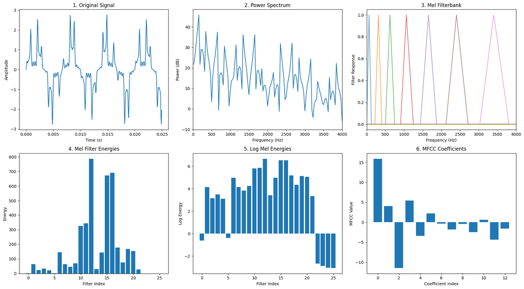

```
MFCC static shape : (98, 13)
MFCC delta  shape : (98, 13)
MFCC d-d   shape : (98, 13)
MFCC combined     : (98, 39)  (13 static + 13 delta + 13 delta-delta)
```

```python
# ===========================================
# MODUL MFCC (Mel-Frequency Cepstral Coefficients)
# Implementasi Lengkap + Visualisasi Step-by-Step
# ===========================================
#
# Referensi Rumus:
# 5.1 Skala Mel:
#   Mel(f) = 2595 * log10(1 + f/700)
#   f = 700 * (10^(Mel/2595) - 1)
#
# 5.2 Mel Filterbank (segitiga overlap):
#   H_m(k) = 0                         , k < f(m-1)
#          = (k-f(m-1))/(f(m)-f(m-1))  , f(m-1) ≤ k ≤ f(m)
#          = (f(m+1)-k)/(f(m+1)-f(m))  , f(m)   ≤ k ≤ f(m+1)
#          = 0                         , k > f(m+1)
#
# 5.3 Energi Filterbank:
#   E(m) = Σ |S(k)|^2 * H_m(k)
#
# 5.4 DCT untuk MFCC:
#   MFCC(n) = Σ log(E(m)) * cos( n (m-0.5) π / M )
#
# 5.5 Delta:
#   Δ_t = Σ n (c_{t+n} - c_{t-n}) / (2 Σ n^2)
#
# 5.6 Delta-Delta:
#   ΔΔ_t = Σ n (Δ_{t+n} - Δ_{t-n}) / (2 Σ n^2)
# ===========================================

import numpy as np
import matplotlib.pyplot as plt
from scipy.fftpack import dct

# ===========================================
# 1) KONVERSI SKALA MEL (5.1)
# ===========================================

def hz_to_mel(hz: float) -> float:
    """Mel(f) = 2595 * log10(1 + f/700)"""
    return 2595.0 * np.log10(1.0 + hz / 700.0)

def mel_to_hz(mel: float) -> float:
    """f = 700 * (10^(Mel/2595) - 1)"""
    return 700.0 * (10.0 ** (mel / 2595.0) - 1.0)

# ===========================================
# 2) PEMBUATAN MEL FILTERBANK (5.2)
# ===========================================

def create_mel_filterbank(
    num_filters: int = 26,
    fft_size: int = 512,
    sample_rate: int = 16000,
    low_freq: float = 0.0,
    high_freq: float | None = None
):
    """
    Membuat bank filter Mel (segitiga overlap) sesuai (5.2).
    Return:
      filterbank: (num_filters, fft_size//2 + 1)
      hz_points : titik frekuensi (Hz) dari boundary & center tiap filter
    """
    if high_freq is None:
        high_freq = sample_rate / 2.0

    # batas ke mel
    low_mel = hz_to_mel(low_freq)
    high_mel = hz_to_mel(high_freq)

    # titik mel terdistribusi merata
    mel_points = np.linspace(low_mel, high_mel, num_filters + 2)
    hz_points = mel_to_hz(mel_points)

    # konversi ke bin FFT
    bin_points = np.floor((fft_size + 1) * hz_points / sample_rate).astype(int)

    # inisialisasi filterbank
    filterbank = np.zeros((num_filters, fft_size // 2 + 1), dtype=float)

    for m in range(1, num_filters + 1):
        left = bin_points[m - 1]    # f(m-1)
        center = bin_points[m]      # f(m)
        right = bin_points[m + 1]   # f(m+1)

        # slope kiri
        if center > left:
            filterbank[m - 1, left:center] = (
                np.arange(left, center) - left
            ) / float(center - left)

        # slope kanan
        if right > center:
            filterbank[m - 1, center:right] = (
                right - np.arange(center, right)
            ) / float(right - center)

    return filterbank, hz_points

# ===========================================
# 3) MFCC PER FRAME: E(m) (5.3) -> log(E) -> DCT (5.4)
# ===========================================

def compute_mfcc(
    signal: np.ndarray,
    sample_rate: int,
    num_mfcc: int = 13,
    num_filters: int = 26,
    fft_size: int = 512
):
    """
    Hitung MFCC untuk satu frame:
      - Pre-emphasis
      - Windowing (Hamming)
      - FFT & Power spectrum
      - Mel filterbank (E(m)) (5.3)
      - log(E(m))
      - DCT (5.4) -> ambil num_mfcc koefisien teratas
    Return:
      mfcc_coefficients: (num_mfcc,)
      log_energies     : (num_filters,)
      filter_energies  : (num_filters,)
    """
    # Pre-emphasis untuk menonjolkan high-freq
    pre_emphasis = 0.97
    emphasized = np.append(signal[0], signal[1:] - pre_emphasis * signal[:-1])

    # Windowing Hamming
    window = np.hamming(len(emphasized))
    windowed = emphasized * window

    # Zero-pad ke fft_size
    if len(windowed) < fft_size:
        padded = np.zeros(fft_size, dtype=float)
        padded[:len(windowed)] = windowed
    else:
        padded = windowed[:fft_size]

    # FFT dan power spectrum
    spectrum = np.abs(np.fft.fft(padded))**2

    # Mel filterbank
    filterbank, _ = create_mel_filterbank(num_filters, fft_size, sample_rate)

    # Energi filterbank (5.3) → hanya pakai bins 0..N/2
    power_half = spectrum[:fft_size // 2 + 1]
    filter_energies = power_half @ filterbank.T  # shape: (num_filters,)

    # log energi (hindari log(0))
    log_energies = np.log(filter_energies + 1e-10)

    # DCT (type II, ortho) untuk MFCC (5.4)
    mfcc_coefficients = dct(log_energies, type=2, norm='ortho')[:num_mfcc]

    return mfcc_coefficients, log_energies, filter_energies

# ===========================================
# 4) DELTA & DELTA-DELTA (5.5, 5.6)
# ===========================================

def compute_delta_coefficients(mfcc_matrix: np.ndarray, N: int = 2) -> np.ndarray:
    """
    Hitung Delta (atau Delta-Delta bila inputnya delta):
    Δ_t = Σ n (c_{t+n} - c_{t-n}) / (2 Σ n^2)
    mfcc_matrix shape: (num_frames, num_coeffs)
    """
    num_frames, num_coeff = mfcc_matrix.shape
    out = np.zeros_like(mfcc_matrix, dtype=float)
    denom = 2 * sum(n**2 for n in range(1, N + 1))

    for t in range(num_frames):
        acc = np.zeros(num_coeff, dtype=float)
        for n in range(1, N + 1):
            t_plus = min(t + n, num_frames - 1)
            t_minus = max(t - n, 0)
            acc += n * (mfcc_matrix[t_plus] - mfcc_matrix[t_minus])
        out[t] = acc / denom

    return out

# ===========================================
# 5) MFCC MULTI-FRAME & KOMBINASI FITUR
# ===========================================

def compute_mfcc_frames(
    audio: np.ndarray,
    sample_rate: int,
    frame_length: int,
    hop_length: int,
    num_mfcc: int = 13,
    num_filters: int = 26,
    fft_size: int = 512
) -> np.ndarray:
    """
    Hitung MFCC untuk banyak frame.
    Return: array shape (num_frames, num_mfcc)
    """
    frames = []
    for i in range(0, len(audio) - frame_length, hop_length):
        frame = audio[i:i + frame_length]
        mfcc_coef, _, _ = compute_mfcc(frame, sample_rate, num_mfcc, num_filters, fft_size)
        frames.append(mfcc_coef)
    return np.array(frames, dtype=float)

def compute_mfcc_with_derivatives(
    audio: np.ndarray,
    sample_rate: int,
    frame_length: int,
    hop_length: int,
    num_mfcc: int = 13,
    num_filters: int = 26,
    fft_size: int = 512
):
    """
    Hitung MFCC static + Delta + Delta-Delta untuk banyak frame.
    Return:
      mfcc_combined: (num_frames, 3*num_mfcc)
      mfcc_static  : (num_frames, num_mfcc)
      mfcc_delta   : (num_frames, num_mfcc)
      mfcc_dd      : (num_frames, num_mfcc)
    """
    mfcc_static = compute_mfcc_frames(audio, sample_rate, frame_length, hop_length,
                                      num_mfcc, num_filters, fft_size)
    mfcc_delta = compute_delta_coefficients(mfcc_static)
    mfcc_dd = compute_delta_coefficients(mfcc_delta)
    mfcc_combined = np.concatenate([mfcc_static, mfcc_delta, mfcc_dd], axis=1)
    return mfcc_combined, mfcc_static, mfcc_delta, mfcc_dd

# ===========================================
# 6) VISUALISASI PIPELINE MFCC (1–6) — CODE ONLY
# ===========================================

def visualize_mfcc_process(signal: np.ndarray, sample_rate: int):
    """
    Visualisasi proses ekstraksi MFCC:
      (1) Sinyal Asli (time)
      (2) Power Spectrum (freq)
      (3) Mel Filterbank
      (4) Mel Filter Energies E(m)
      (5) Log Mel Energies log(E(m))
      (6) Koefisien MFCC (DCT)
    """
    fig, axes = plt.subplots(2, 3, figsize=(18, 10))

    # 1. Original signal
    t = np.arange(len(signal)) / sample_rate
    axes[0, 0].plot(t, signal)
    axes[0, 0].set_title('1. Original Signal')
    axes[0, 0].set_xlabel('Time (s)')
    axes[0, 0].set_ylabel('Amplitude')

    # 2. Power spectrum
    fft_size = 512
    padded_signal = np.zeros(fft_size, dtype=float)
    padded_signal[:len(signal)] = signal
    power_spectrum = np.abs(np.fft.fft(padded_signal)) ** 2
    freqs = np.fft.fftfreq(fft_size, 1 / sample_rate)[:fft_size // 2]

    axes[0, 1].plot(freqs, 10 * np.log10(power_spectrum[:fft_size // 2] + 1e-10))
    axes[0, 1].set_title('2. Power Spectrum')
    axes[0, 1].set_xlabel('Frequency (Hz)')
    axes[0, 1].set_ylabel('Power (dB)')
    axes[0, 1].set_xlim(0, 4000)

    # 3. Mel filterbank
    num_filters = 26
    filterbank, hz_points = create_mel_filterbank(num_filters, fft_size, sample_rate)

    for i in range(0, num_filters, 3):  # plot tiap 3 filter agar jelas
        filter_freqs = np.linspace(0, sample_rate / 2, fft_size // 2 + 1)
        axes[0, 2].plot(filter_freqs, filterbank[i], alpha=0.7)

    axes[0, 2].set_title('3. Mel Filterbank')
    axes[0, 2].set_xlabel('Frequency (Hz)')
    axes[0, 2].set_ylabel('Filter Response')
    axes[0, 2].set_xlim(0, 4000)

    # 4–6. MFCC untuk frame ini
    mfcc_coef, log_energies, filter_energies = compute_mfcc(signal, sample_rate)

    # 4. Mel Energies
    axes[1, 0].bar(range(len(filter_energies)), filter_energies)
    axes[1, 0].set_title('4. Mel Filter Energies')
    axes[1, 0].set_xlabel('Filter Index')
    axes[1, 0].set_ylabel('Energy')

    # 5. Log Mel Energies
    axes[1, 1].bar(range(len(log_energies)), log_energies)
    axes[1, 1].set_title('5. Log Mel Energies')
    axes[1, 1].set_xlabel('Filter Index')
    axes[1, 1].set_ylabel('Log Energy')

    # 6. MFCC Coefficients
    axes[1, 2].bar(range(len(mfcc_coef)), mfcc_coef)
    axes[1, 2].set_title('6. MFCC Coefficients')
    axes[1, 2].set_xlabel('Coefficient Index')
    axes[1, 2].set_ylabel('MFCC Value')

    plt.tight_layout()
    plt.show()

# ===========================================
# 7) DEMO / PENGUJIAN
# ===========================================

if __name__ == "__main__":
    print("=== DEMO MFCC MODULE ===")
    fs = 16000

    # ---- Frame singkat (25 ms) untuk pipeline visualisasi 1–6 ----
    dur_frame = 0.025  # 25 ms
    t_frame = np.linspace(0, dur_frame, int(fs * dur_frame), endpoint=False)

    # Simulasi sinyal “vokal” sederhana: F0 * (formant envelopes)
    f0 = 150.0
    f1, f2, f3 = 500.0, 1500.0, 2500.0
    formant_signal = (
        np.sin(2 * np.pi * f0 * t_frame)
        * (1 + 0.8 * np.sin(2 * np.pi * f1 * t_frame))
        * (1 + 0.6 * np.sin(2 * np.pi * f2 * t_frame))
        * (1 + 0.4 * np.sin(2 * np.pi * f3 * t_frame))
    )

    # Visualisasi pipeline MFCC (1–6) untuk 1 frame
    visualize_mfcc_process(formant_signal, fs)

    # ---- Sinyal 1 detik untuk MFCC multi-frame + Delta + Delta-Delta ----
    duration = 1.0
    t_long = np.linspace(0, duration, int(fs * duration), endpoint=False)

    # Variasi pitch F0 kontinyu
    f0_contour = 150.0 + 50.0 * np.sin(2 * np.pi * 2 * t_long)
    speech_signal = np.sin(2 * np.pi * f0_contour * t_long)

    # Tambahkan envelope “formant” sederhana
    formant_env = (1 + 0.8 * np.sin(2 * np.pi * 500 * t_long)
                     + 0.6 * np.sin(2 * np.pi * 1500 * t_long))
    speech_signal *= formant_env

    # Parameter framing
    frame_len = int(0.025 * fs)  # 25 ms
    hop_len = int(0.010 * fs)    # 10 ms

    # Hitung MFCC + turunan
    mfcc_all, mfcc_static, mfcc_delta, mfcc_delta2 = compute_mfcc_with_derivatives(
        speech_signal, fs, frame_len, hop_len
    )

    print(f"MFCC static shape : {mfcc_static.shape}")
    print(f"MFCC delta  shape : {mfcc_delta.shape}")
    print(f"MFCC d-d   shape : {mfcc_delta2.shape}")
    print(f"MFCC combined     : {mfcc_all.shape}  (13 static + 13 delta + 13 delta-delta)")
```

Interpretasi di atas adalah pipeline MFCC dari sinyal waktu sampai koefisien cepstral.

1. Original Signal

Potongan sinyal audio di domain waktu. Puncak-lembah cepat menandakan ada komponen frekuensi menengah/tinggi; bagian yang relatif halus → komponen frekuensi rendah. Ini bahan mentah sebelum dianalisis.

2. Power Spectrum

Spektrum daya (dB) setelah STFT/FFT. Puncak-puncak di frekuensi tertentu menunjukkan harmonik/komponen kuat. Di sinilah energi frekuensi berada sebelum “diproyeksikan” ke skala mel.

3. Mel Filterbank

Kumpulan filter segitiga yang tumpang tindih pada sumbu frekuensi tetapi **berjarak merata pada skala mel** (meniru kepekaan telinga: rapat di frekuensi rendah, jarang di tinggi). Setiap filter akan “mengumpulkan” energi dari rentang frekuensi kecil.

4. Mel Filter Energies

Hasil menjumlahkan spektrum-daya yang ditimbang oleh masing-masing filter Mel. Bar tinggi = banyak energi pada rentang frekuensi filter tersebut. Terlihat beberapa filter (sekitar tengah) menyerap energi paling besar → di spektrum ada puncak pada area itu.

5. Log Mel Energies

Energi Mel diubah ke **log** (ln atau dB). Dua fungsi:

1. mendekatkan skala ke persepsi manusia (loudness),
2. menstabilkan dinamika (mengompresi nilai yang sangat besar). Pola bar tetap sama, tetapi rentangnya lebih “ketat”.
3. MFCC Coefficients

DCT (Discrete Cosine Transform) terhadap vektor log-Mel menghasilkan **MFCC**:

- **c0** (bar pertama) ≈ ringkasan **log-energi keseluruhan**.
- **Koefisien rendah (c1–c4)** menangkap **bentuk amplop spektral kasar** (formant/envelope).
- **Koefisien lebih tinggi** memodelkan detail halus; biasanya kecil dan sering diabaikan/di-lifter. Terlihat c0 paling besar, c1–c3 masih signifikan, lalu cepat mengecil—ini khas MFCC.

Maka dari itu:

1. **Waktu → Frekuensi** (Power Spectrum)
2. **Frekuensi → Skala Mel** (Filterbank)
3. **Linear → Log** (Log Mel Energies)
4. **Log-Mel → Domain Cepstral** (DCT → MFCC)

MFCC memberi representasi ringkas yang fokus pada **amplop spektral**—fitur yang paling informatif untuk ucapan/musik—dengan hanya belasan angka per frame.

```python
def compute_mfcc_frames(audio, sample_rate, frame_length, hop_length,
                       num_mfcc=13, num_filters=26, fft_size=512):
    r"""
    Hitung MFCC untuk multiple frames audio

    **Langkah-langkah:**
    1. Potong sinyal menjadi frame dengan panjang `frame_length` dan pergeseran `hop_length`.
    2. Untuk tiap frame, hitung koefisien MFCC dengan:

       - Energi Mel Filterbank:
         \[
         E(m) = \sum_{k=0}^{N/2-1} |S(k)|^2 \cdot H_m(k)
         \]
         di mana \(S(k)\) adalah spektrum FFT dan \(H_m(k)\) adalah respons filter Mel ke-m.

       - Koefisien MFCC (Discrete Cosine Transform):
         \[
         MFCC(n) = \sum_{m=1}^{M} \log(E(m)) \cdot
                   \cos\Bigl( n(m - 0.5)\frac{\pi}{M} \Bigr)
         \]

    Parameters
    ----------
    audio : array
        Sinyal audio input.
    sample_rate : int
        Sample rate sinyal.
    frame_length : int
        Panjang frame (dalam samples).
    hop_length : int
        Pergeseran antar frame (dalam samples).
    num_mfcc : int, optional
        Jumlah koefisien MFCC yang dihitung (default: 13).
    num_filters : int, optional
        Jumlah filter pada Mel filterbank (default: 26).
    fft_size : int, optional
        Ukuran FFT (default: 512).

    Returns
    -------
    np.ndarray
        Matriks MFCC dengan bentuk (num_frames, num_mfcc).
    """

    mfcc_frames = []

    # Looping frame demi frame
    for i in range(0, len(audio) - frame_length, hop_length):
        frame = audio[i:i+frame_length]

        # Hitung MFCC untuk frame ini
        mfcc_coef, _, _ = compute_mfcc(frame, sample_rate, num_mfcc,
                                       num_filters, fft_size)
        mfcc_frames.append(mfcc_coef)

    return np.array(mfcc_frames)


def compute_mfcc_with_derivatives(audio, sample_rate, frame_length, hop_length):
    r"""
    Hitung MFCC lengkap dengan turunan pertama (delta) dan turunan kedua (delta-delta).

    **Langkah-langkah:**
    1. Hitung **MFCC statis** untuk setiap frame dengan DCT dari log-energi filterbank.
    2. Hitung **delta coefficients**:
       \[
       \Delta_t = \frac{\sum_{n=1}^{N} n \cdot (c_{t+n} - c_{t-n})}
                       {2 \cdot \sum_{n=1}^{N} n^2}
       \]
       di mana \(c_t\) adalah koefisien MFCC pada frame ke-t.
    3. Hitung **delta-delta coefficients** dengan cara yang sama,
       tetapi inputnya adalah matriks delta.

    4. Gabungkan semua fitur menjadi satu vektor per frame:
       \[
       \text{Fitur} = [MFCC \;|\; \Delta \;|\; \Delta\Delta]
       \]

    Parameters
    ----------
    audio : array
        Sinyal audio input.
    sample_rate : int
        Sample rate sinyal.
    frame_length : int
        Panjang frame dalam samples.
    hop_length : int
        Pergeseran antar frame dalam samples.

    Returns
    -------
    tuple
        (mfcc_combined, mfcc_static, mfcc_delta, mfcc_delta_delta)
        - mfcc_combined: Fitur gabungan (num_frames, 39) jika num_mfcc=13.
        - mfcc_static: MFCC statis.
        - mfcc_delta: Koefisien delta.
        - mfcc_delta_delta: Koefisien delta-delta.
    """

    # Static MFCC
    mfcc_static = compute_mfcc_frames(audio, sample_rate, frame_length, hop_length)

    # Delta coefficients (turunan pertama)
    mfcc_delta = compute_delta_coefficients(mfcc_static)

    # Delta-delta coefficients (turunan kedua)
    mfcc_delta_delta = compute_delta_coefficients(mfcc_delta)

    # Gabungkan semua fitur per frame
    mfcc_combined = np.concatenate([mfcc_static, mfcc_delta, mfcc_delta_delta], axis=1)

    return mfcc_combined, mfcc_static, mfcc_delta, mfcc_delta_delta


# ===========================================
# TESTING DENGAN SINTESIS SINYAL
# ===========================================

duration = 1.0  # 1 detik
t_long = np.linspace(0, duration, int(fs * duration))

# Simulasi ucapan dengan pitch yang bervariasi (F0 contour)
f0_contour = 150 + 50 * np.sin(2*np.pi*2*t_long)
speech_signal = np.sin(2*np.pi*f0_contour*t_long)

# Tambahkan formant (resonansi vokal tipikal ucapan manusia)
formant_envelope = (1 + 0.8*np.sin(2*np.pi*500*t_long) +
                   0.6*np.sin(2*np.pi*1500*t_long))
speech_signal *= formant_envelope

# Parameter frame
frame_len = int(0.025 * fs)  # 25 ms
hop_len = int(0.010 * fs)    # 10 ms

# Hitung MFCC lengkap
mfcc_all, mfcc_static, mfcc_delta, mfcc_delta2 = compute_mfcc_with_derivatives(
    speech_signal, fs, frame_len, hop_len)

print(f"MFCC static shape   : {mfcc_static.shape}")
print(f"MFCC delta shape    : {mfcc_delta.shape}")
print(f"MFCC combined shape : {mfcc_all.shape}")
```

```
MFCC static shape   : (98, 13)
MFCC delta shape    : (98, 13)
MFCC combined shape : (98, 39)
```

#### Normalisasi MFCC

1. Cepstral Mean Subtraction (CMS) $\hat{c}_n = c_n - \frac{1}{T} \sum_{t=1}^{T} c_n(t)$

dimana $\hat{c}_n$ adalah MFCC yang dinormalisasi dan $T$ adalah jumlah frame.

2. Cepstral Variance Normalization (CVN) $\hat{c}_n = \frac{c_n - \mu_n}{\sigma_n + \epsilon}$

dimana $\mu_n$ dan $\sigma_n$ adalah mean dan standard deviation koefisien ke-$n$, dan $\epsilon$ adalah small constant untuk numerik stability.

3. Liftering $\hat{c}_n = c_n \cdot w_n$

dimana $w_n = 1 + \frac{L}{2} \sin\left(\frac{\pi n}{L}\right)$ dan $L$ adalah liftering parameter (biasanya 22).

#### Interpretasi Koefisien MFCC

Makna Setiap Koefisien:

- **C0**: Log energy total (sering diabaikan dalam speech recognition)
- **C1-C3**: Envelope spektral kasar, berkorelasi dengan formant rendah
- **C4-C8**: Detail spektral menengah, karakteristik vokal dan speaker
- **C9-C12**: Detail spektral halus, noise-sensitive tapi penting untuk akurasi

Karakteristik untuk Berbagai Bunyi:

| Bunyi | C1 | C2 | C3 | Karakteristik |
| --- | --- | --- | --- | --- |
| Vokal /a/ | Tinggi | Sedang | Rendah | Formant rendah dominan |
| Vokal /i/ | Rendah | Tinggi | Sedang | Formant tinggi (F2) |
| Frikatif /s/ | Rendah | Rendah | Tinggi | Energi frekuensi tinggi |
| Nasal /m/ | Sedang | Rendah | Rendah | Anti-formant effect |

```python
# ===========================================
# Normalisasi & Liftering MFCC (CMS, CVN, Lifter)
# Dengan docstring berisi rumus dan komentar langkah
# ===========================================

import numpy as np

def apply_cepstral_mean_normalization(mfcc_matrix: np.ndarray):
    r"""
    Terapkan **Cepstral Mean Subtraction (CMS)** pada matriks MFCC.

    **Rumus (5.7):**
    \[
      \hat{c}_n(t) \;=\; c_n(t) \;-\; \frac{1}{T}\sum_{t=1}^{T} c_n(t)
    \]
    di mana:
    - \( c_n(t) \)  : koefisien MFCC ke-\(n\) pada frame \(t\)
    - \( \hat{c}_n(t) \) : koefisien MFCC setelah normalisasi mean
    - \( T \)       : jumlah frame

    **Intuisi:** menghilangkan bias saluran (channel bias) per-koefisien
    dengan menggeser rata-rata menjadi nol (zero-mean).

    Parameters
    ----------
    mfcc_matrix : np.ndarray
        Matriks MFCC berukuran (num_frames, num_coeff). Setiap kolom adalah
        satu koefisien (C0..C_{K-1}) sepanjang waktu.

    Returns
    -------
    normalized_mfcc : np.ndarray
        MFCC setelah mean subtraction, shape (num_frames, num_coeff).
    mean_mfcc : np.ndarray
        Vektor mean per koefisien sebelum normalisasi, shape (num_coeff,).

    Notes
    -----
    - CMS umumnya dilakukan **per-utterance** (satu potongan ucapan) agar
      robust terhadap perbedaan saluran/rekaman.
    - Beberapa pipeline menghapus C0 (log-energi) sebelum normalisasi
      tergantung desain sistem.
    """
    # 1) Hitung mean per koefisien (kolom) di seluruh frame (baris)
    mean_mfcc = np.mean(mfcc_matrix, axis=0)

    # 2) Kurangi setiap nilai dengan mean koefisiennya (zero-centering per kolom)
    normalized_mfcc = mfcc_matrix - mean_mfcc

    return normalized_mfcc, mean_mfcc


def apply_cepstral_variance_normalization(mfcc_matrix: np.ndarray, eps: float = 1e-8):
    r"""
    Terapkan **Cepstral Variance Normalization (CVN)** pada matriks MFCC.

    **Rumus (5.8):**
    \[
      \hat{c}_n(t) \;=\; \frac{c_n(t) - \mu_n}{\sigma_n + \epsilon}
    \]
    di mana:
    - \( \mu_n \), \( \sigma_n \) : mean dan standar deviasi koefisien ke-\(n\)
    - \( \epsilon \) : konstanta kecil untuk stabilitas numerik

    **Intuisi:** menormalkan setiap koefisien agar memiliki rata-rata 0 dan
    deviasi standar 1 (z-score), sehingga lebih robust terhadap variasi
    speaker/lingkungan.

    Parameters
    ----------
    mfcc_matrix : np.ndarray
        Matriks MFCC berukuran (num_frames, num_coeff).
    eps : float, optional
        Small constant untuk mencegah pembagian nol, default 1e-8.

    Returns
    -------
    normalized_mfcc : np.ndarray
        MFCC setelah z-score normalization, shape (num_frames, num_coeff).
    mean_mfcc : np.ndarray
        Vektor mean per koefisien sebelum normalisasi, shape (num_coeff,).
    std_mfcc : np.ndarray
        Vektor standar deviasi per koefisien sebelum normalisasi, shape (num_coeff,).

    Notes
    -----
    - CVN bisa diterapkan setelah CMS (urutan umum: CMS -> CVN).
    - Lakukan per-utterance atau per-speaker tergantung skenario.
    """
    # 1) Hitung mean & std per koefisien
    mean_mfcc = np.mean(mfcc_matrix, axis=0)
    std_mfcc = np.std(mfcc_matrix, axis=0)

    # 2) Z-score normalization dengan penambahan epsilon
    normalized_mfcc = (mfcc_matrix - mean_mfcc) / (std_mfcc + eps)

    return normalized_mfcc, mean_mfcc, std_mfcc


def apply_liftering(mfcc_matrix: np.ndarray, L: int = 22):
    r"""
    Terapkan **liftering** untuk “menyeimbangkan” skala koefisien MFCC.

    **Rumus (5.9):**
    \[
      \hat{c}_n(t) \;=\; c_n(t) \cdot w_n, \quad
      w_n \;=\; 1 + \frac{L}{2}\,\sin\!\Bigl(\frac{\pi n}{L}\Bigr)
    \]
    di mana:
    - \( L \) : parameter liftering (umum digunakan \(L=22\))
    - \( n \) : indeks koefisien cepstral (0..K-1)

    **Intuisi:** liftering menurunkan dominasi koefisien rendah/tinggi tertentu
    dan menghaluskan (smoothing) pola koefisien agar informasi bentuk spektral
    (envelope) lebih stabil.

    Parameters
    ----------
    mfcc_matrix : np.ndarray
        Matriks MFCC berukuran (num_frames, num_coeff).
    L : int, optional
        Parameter liftering (default 22). Semakin besar L, efek osilasi bobot
        makin halus.

    Returns
    -------
    liftered_mfcc : np.ndarray
        MFCC setelah liftering, shape (num_frames, num_coeff).
    lifter_weights : np.ndarray
        Bobot liftering \(w_n\), shape (num_coeff,).

    Notes
    -----
    - Praktik umum: liftering diterapkan pada **MFCC statis** (sebelum
      menghitung Delta & Delta-Delta) agar turunan tidak “mengamplifikasi”
      ketidakseimbangan skala.
    - C0 (log-energi) dapat dikecualikan dari liftering bila diinginkan.
    """
    # 1) Bentuk bobot liftering untuk setiap koefisien n = 0..K-1
    n = np.arange(mfcc_matrix.shape[1])
    lifter_weights = 1.0 + (L / 2.0) * np.sin(np.pi * n / L)

    # 2) Aplikasikan liftering secara per-koefisien (broadcast ke seluruh frame)
    liftered_mfcc = mfcc_matrix * lifter_weights

    return liftered_mfcc, lifter_weights


# ===========================================
# Contoh Penggunaan / Pengujian Singkat
# (asumsikan variabel `mfcc_static` sudah tersedia
#  dengan shape (num_frames, num_mfcc))
# ===========================================

# Komentar: Cetak statistik awal 5 koefisien pertama (C0..C4)
print("Original MFCC stats:")
print(f"Mean: {np.mean(mfcc_static, axis=0)[:5]}")
print(f"Std:  {np.std(mfcc_static, axis=0)[:5]}")

# 1) CMS: zero-mean per koefisien
mfcc_cms, mean_vec = apply_cepstral_mean_normalization(mfcc_static)
print("\nAfter CMS:")
print(f"Mean: {np.mean(mfcc_cms, axis=0)[:5]}")   # ≈ 0
print(f"Std:  {np.std(mfcc_cms, axis=0)[:5]}")    # tidak dinormalisasi varian

# 2) CVN: z-score (mean≈0, std≈1)
mfcc_cvn, mean_vec_cvn, std_vec_cvn = apply_cepstral_variance_normalization(mfcc_static)
print("\nAfter CVN:")
print(f"Mean: {np.mean(mfcc_cvn, axis=0)[:5]}")   # ≈ 0
print(f"Std:  {np.std(mfcc_cvn, axis=0)[:5]}")    # ≈ 1

# 3) Liftering: skala tiap koefisien dengan w_n
mfcc_liftered, weights = apply_liftering(mfcc_static, L=22)
print("\nAfter Liftering:")
print(f"weights[:5]: {weights[:5]}")              # contoh bobot untuk C0..C4
print(f"Mean (liftered)[:5]: {np.mean(mfcc_liftered, axis=0)[:5]}")
print(f"Std  (liftered)[:5]: {np.std(mfcc_liftered, axis=0)[:5]}")

# Catatan urutan rekomendasi (opsional):
# - Hitung MFCC statis -> liftering -> (opsional) gabung dengan Delta & Delta-Delta
# - Normalisasi (CMS/CVN) dilakukan per-utterance sebelum model/klasifier
```

```
Original MFCC stats:
Mean: [-2.76077563 10.29424709 -4.71417795 -4.20147708  2.69696552]
Std:  [4.86156895 3.21053326 2.1882649  1.56522422 1.82697087]

After CMS:
Mean: [ 1.42289808e-15  9.06304510e-17 -1.63134812e-16 -7.70358833e-16
  0.00000000e+00]
Std:  [4.86156895 3.21053326 2.1882649  1.56522422 1.82697087]

After CVN:
Mean: [ 2.22044605e-16  1.81260902e-17 -1.81260902e-17 -6.34413157e-16
 -1.29148393e-16]
Std:  [1.         1.         1.         0.99999999 0.99999999]

After Liftering:
weights[:5]: [1.         2.56546322 4.09905813 5.56956514 6.94704899]
Mean (liftered)[:5]: [ -2.76077563  26.4095123  -19.32368944 -23.40040029  18.73595162]
Std  (liftered)[:5]: [ 4.86156895  8.236505    8.969825    8.71761825 12.69205611]
```

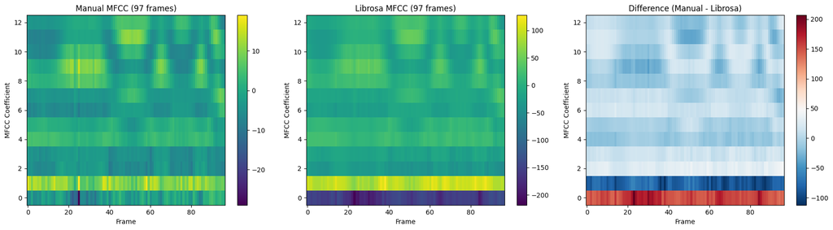

```
Comparison Statistics:
MSE                      : 2670.609835
Correlation              : 0.652044
Maximum absolute diff    : 206.777751
Mean absolute diff (MAD) : 30.355992
❌ Low correlation - significant differences found
```

```python
def compare_with_librosa_mfcc(audio, sample_rate):
    r"""
    Bandingkan **implementasi MFCC manual** (pipeline kita) dengan **librosa.feature.mfcc**.

    **Tujuan:** memverifikasi kesetaraan konsep melalui *shape*, visual (heatmap), dan metrik selisih (MSE, korelasi).

    -----------------------------
    ## Ringkasan Rumus yang Dibandingkan
    1) **Spektrum daya**:
       \[
         P(k) = |FFT(x)|^2
       \]
    2) **Mel filterbank** (segitiga overlap, (5.2)):
       \[
       H_m(k)=
       \begin{cases}
       0, & k<f(m-1)\\
       \frac{k-f(m-1)}{f(m)-f(m-1)}, & f(m-1)\le k\le f(m)\\
       \frac{f(m+1)-k}{f(m+1)-f(m)}, & f(m)\le k\le f(m+1)\\
       0, & k>f(m+1)
       \end{cases}
       \]
    3) **Energi filter Mel** (5.3):
       \[
         E(m) = \sum_{k=0}^{N/2-1} P(k)\,H_m(k)
       \]
    4) **MFCC via DCT** (5.4):
       \[
         MFCC(n)=\sum_{m=1}^{M}\log(E(m))\cos\!\Bigl(n(m-0.5)\frac{\pi}{M}\Bigr)
       \]
    5) **Skala Mel** yang dipakai manual (HTK) (5.1):
       \[
         \text{Mel}(f)=2595\log_{10}\bigl(1+\tfrac{f}{700}\bigr)
       \]
       (Librosa default = Slaney; agar konsisten, set `htk=True`.)

    -----------------------------
    ## Catatan Penyelarasan Parameter agar Hasil Lebih Mirip
    - **Pre-emphasis**: manual memakai \(\alpha=0.97\). Librosa tidak otomatis;
      maka audio untuk librosa kita **pre-emphasis** terlebih dulu.
    - **Jendela & Pusat bingkai**: manual pakai **Hamming** dan `center=False`;
      librosa disetel sama: `window='hamming'`, `center=False`.
    - **Ukuran FFT (zero-padding)**: manual zero-pad ke `fft_size=512`.
      Librosa diselaraskan ke **`n_fft = next_power_of_two(win_length)`** (biasanya 512 untuk 25 ms @ 16 kHz).
    - **Jumlah filter Mel**: manual ~26; librosa disetel `n_mels=26`.
    - **Rentang frekuensi**: `fmin=0`, `fmax=sr/2`.
    - **Skala Mel**: pakai **HTK** (`htk=True`) agar cocok dengan rumus (5.1).
    - **Normalisasi filter**: set `norm=None` (agar tinggi segitiga tidak dinormalisasi ala Slaney).

    Returns
    -------
    (np.ndarray, np.ndarray)
        mfcc_manual_trimmed, mfcc_librosa_trimmed — keduanya berukuran (min_frames, 13)
        sehingga bisa langsung dibandingkan frame-by-frame.

    Side Effects
    ------------
    - Mencetak shape, statistik MSE/korelasi, dan menampilkan heatmap:
      (Manual), (Librosa), dan (Difference = Manual - Librosa).
    """
    try:
        import numpy as np
        import matplotlib.pyplot as plt
        import librosa

        # -----------------------------
        # 1) Parameter framing yang sama dengan implementasi manual
        # -----------------------------
        frame_len = int(0.025 * sample_rate)   # 25 ms
        hop_len   = int(0.010 * sample_rate)   # 10 ms

        # Ukuran FFT untuk menyamai zero-padding manual (≈512 untuk 16 kHz @ 25 ms)
        # Pilih pangkat dua terdekat >= frame_len
        def _next_pow2(n: int) -> int:
            p = 1
            while p < n:
                p <<= 1
            return p
        n_fft = max(512, _next_pow2(frame_len))  # paksa >=512 agar konsisten dengan pipeline manual

        # -----------------------------
        # 2) MFCC manual (pipeline kita)
        # -----------------------------
        mfcc_manual = compute_mfcc_frames(
            audio, sample_rate,
            frame_length=frame_len,
            hop_length=hop_len,
            num_mfcc=13, num_filters=26, fft_size=n_fft
        )  # shape: (num_frames, 13)

        # -----------------------------
        # 3) MFCC via librosa
        #    - Pre-emphasis audio agar sejajar dengan manual
        #    - Window hamming, center=False
        #    - n_fft = n_fft (pow2 >= frame_len)
        #    - n_mels = 26, htk=True, norm=None, fmin=0, fmax=sr/2
        # -----------------------------
        pre_emphasis = 0.97
        audio_preemph = np.append(audio[0], audio[1:] - pre_emphasis * audio[:-1])

        mfcc_librosa = librosa.feature.mfcc(
            y=audio_preemph,
            sr=sample_rate,
            n_mfcc=13,
            n_fft=n_fft,
            hop_length=hop_len,
            win_length=frame_len,
            window='hamming',
            center=False,
            # parameter Mel agar mendekati definisi manual:
            n_mels=26,
            htk=True,
            fmin=0.0,
            fmax=sample_rate / 2.0,
            norm='ortho',   # DCT norm ortho (default librosa) — sama dengan manual
            # lifter=0      # nonaktifkan liftering agar setara
        )
        # Librosa mengembalikan shape (n_mfcc, num_frames) -> transpose agar (num_frames, n_mfcc)
        mfcc_librosa = mfcc_librosa.T

        # -----------------------------
        # 4) Samakan jumlah frame (trim ke minimum)
        # -----------------------------
        min_frames = min(mfcc_manual.shape[0], mfcc_librosa.shape[0])
        mfcc_manual_trimmed  = mfcc_manual[:min_frames, :]
        mfcc_librosa_trimmed = mfcc_librosa[:min_frames, :]

        # -----------------------------
        # 5) Visualisasi perbandingan (heatmap)
        # -----------------------------
        fig, axes = plt.subplots(1, 3, figsize=(18, 5))

        im1 = axes[0].imshow(mfcc_manual_trimmed.T, aspect='auto', origin='lower', cmap='viridis')
        axes[0].set_title(f'Manual MFCC ({mfcc_manual_trimmed.shape[0]} frames)')
        axes[0].set_xlabel('Frame')
        axes[0].set_ylabel('MFCC Coefficient')
        plt.colorbar(im1, ax=axes[0])

        im2 = axes[1].imshow(mfcc_librosa_trimmed.T, aspect='auto', origin='lower', cmap='viridis')
        axes[1].set_title(f'Librosa MFCC ({mfcc_librosa_trimmed.shape[0]} frames)')
        axes[1].set_xlabel('Frame')
        axes[1].set_ylabel('MFCC Coefficient')
        plt.colorbar(im2, ax=axes[1])

        diff = mfcc_manual_trimmed - mfcc_librosa_trimmed
        im3 = axes[2].imshow(diff.T, aspect='auto', origin='lower', cmap='RdBu_r')
        axes[2].set_title('Difference (Manual - Librosa)')
        axes[2].set_xlabel('Frame')
        axes[2].set_ylabel('MFCC Coefficient')
        plt.colorbar(im3, ax=axes[2])

        plt.tight_layout()
        plt.show()

        # -----------------------------
        # 6) Statistik selisih
        # -----------------------------
        mse = np.mean((mfcc_manual_trimmed - mfcc_librosa_trimmed) ** 2)
        correlation = np.corrcoef(
            mfcc_manual_trimmed.flatten(),
            mfcc_librosa_trimmed.flatten()
        )[0, 1]
        max_diff = np.max(np.abs(diff))
        mad = np.mean(np.abs(diff))

        print("\nComparison Statistics:")
        print(f"MSE                      : {mse:.6f}")
        print(f"Correlation              : {correlation:.6f}")
        print(f"Maximum absolute diff    : {max_diff:.6f}")
        print(f"Mean absolute diff (MAD) : {mad:.6f}")

        if correlation > 0.9:
            print("✅ High correlation - implementations are very similar!")
        elif correlation > 0.7:
            print("⚠️  Moderate correlation - some differences exist")
        else:
            print("❌ Low correlation - significant differences found")

        return mfcc_manual_trimmed, mfcc_librosa_trimmed

    except ImportError:
        print("Librosa not available for comparison")
        return None, None
# Test comparison
mfcc_manual, mfcc_librosa = compare_with_librosa_mfcc(speech_signal, fs)
```

```python
def simple_speech_classifier_mfcc(
    training_data,
    training_labels,
    test_data,
    sample_rate,
    frame_ms: float = 25.0,
    hop_ms: float = 10.0,
    num_mfcc: int = 13,
    use_delta: bool = True,
    use_delta_delta: bool = True,
    apply_cms: bool = True,
    apply_cvn: bool = True,
    lifter_L: int | None = None,
    svm_kernel: str = "rbf",
    C: float = 1.0,
    gamma: str | float = "scale",
    random_state: int | None = 42,
):
    r"""
    Klasifikasi sederhana berbasis **MFCC** + ringkasan statistik + **SVM**.

    Pipeline (per-utterance):
      1) Ekstraksi frame (window) dari sinyal
         - Panjang frame = `frame_ms` ms, hop = `hop_ms` ms.
      2) Hitung MFCC (opsional: +Δ, +ΔΔ), lalu normalisasi (CMS/CVN) & liftering.
      3) Ringkas jadi 1 vektor fitur per utterance via statistik:
         - Mean, Std, Max, Min untuk setiap koefisien (→ **4 × D** dimensi).
      4) Standarisasi fitur global (z-score) → latih **SVM** → prediksi.

    -----------------------------
    # Rumus-Rumus Inti
    1) **Mel scale** (5.1):
       \[
         \text{Mel}(f)=2595\log_{10}\Bigl(1+\frac{f}{700}\Bigr)
       \]

    2) **Energi filterbank Mel** (5.3):
       \[
         E(m) = \sum_{k=0}^{N/2-1} \lvert S(k) \rvert^2 \, H_m(k)
       \]

    3) **Discrete Cosine Transform (MFCC)** (5.4):
       \[
         \mathrm{MFCC}(n) = \sum_{m=1}^{M}\log(E(m))\,
           \cos\!\Bigl(n(m-0.5)\frac{\pi}{M}\Bigr)
       \]

    4) **Delta / Delta-Delta** (5.5, 5.6) untuk setiap koefisien \(c_t\):
       \[
         \Delta_t =
         \frac{\sum_{n=1}^{N} n\,(c_{t+n}-c_{t-n})}{2\sum_{n=1}^{N} n^2},
         \qquad
         \Delta\Delta_t =
         \frac{\sum_{n=1}^{N} n\,(\Delta_{t+n}-\Delta_{t-n})}{2\sum_{n=1}^{N} n^2}
       \]

    5) **Normalisasi Cepstral**:
       - **CMS** (5.7): \(\hat{c}_n(t)=c_n(t)-\frac{1}{T}\sum_{t=1}^{T}c_n(t)\)
       - **CVN** (5.8): \(\hat{c}_n = \frac{c_n-\mu_n}{\sigma_n+\epsilon}\)

    6) **Liftering** (5.9):
       \[
         \hat{c}_n = c_n \cdot w_n,\quad
         w_n = 1 + \frac{L}{2}\sin\!\Bigl(\frac{\pi n}{L}\Bigr)
       \]

    7) **Ringkasan Statistik** (per koefisien \(d\)):
       \[
         \mu_d=\text{mean}(c_d),\quad
         \sigma_d=\text{std}(c_d),\quad
         \max_d,\ \min_d
       \]
       Fitur utterance = \([\mu\ |\ \sigma\ |\ \max\ |\ \min]\) → dimensi = \(4\times D\).

    8) **SVM** (kernel RBF):
       - Keputusan: \(\operatorname{sign}\Bigl(\sum_i \alpha_i y_i K(x_i, x) + b\Bigr)\)
       - Kernel RBF: \(K(x,z) = \exp(-\gamma \|x-z\|^2)\)

    Parameters
    ----------
    training_data : list[np.ndarray]
        List sinyal audio latih (1D) dengan sample_rate sama.
    training_labels : list/np.ndarray
        Label untuk setiap audio latih.
    test_data : list[np.ndarray]
        List sinyal audio uji (1D).
    sample_rate : int
        Sample rate semua sinyal.
    frame_ms, hop_ms : float
        Lama frame & hop (ms).
    num_mfcc : int
        Jumlah koefisien MFCC statis.
    use_delta, use_delta_delta : bool
        Tambah Δ, ΔΔ ke matriks MFCC per-frame sebelum diringkas.
    apply_cms, apply_cvn : bool
        Terapkan CMS/CVN antar-frame (per utterance).
    lifter_L : int | None
        Jika tidak None, terapkan liftering dengan parameter L.
    svm_kernel : str
        Kernel SVM (default "rbf").
    C : float
        Regularisasi SVM.
    gamma : str | float
        Parameter kernel RBF.
    random_state : int | None
        Seed untuk reprodusibilitas.

    Returns
    -------
    predictions : np.ndarray
        Prediksi label untuk `test_data`.
    classifier : sklearn.svm.SVC
        Model SVM terlatih.
    scaler : sklearn.preprocessing.StandardScaler
        Scaler yang dipakai untuk fitur.
    feature_names : list[str]
        Nama fitur dalam urutan yang sesuai dengan vektor fitur.
    """
    import numpy as np
    from sklearn.svm import SVC
    from sklearn.preprocessing import StandardScaler

    # ---- helper kecil -------------------------------------------------------
    def _frames_to_feature_vector(mfcc_frames_2d: np.ndarray) -> np.ndarray:
        """
        Ubah matriks (num_frames, D) → vektor (4D) via [mean|std|max|min].
        """
        # (1) opsional normalisasi per-utterance
        feats = mfcc_frames_2d
        if lifter_L is not None:
            feats, _ = apply_liftering(feats, L=lifter_L)  # smoothing koefisien

        if apply_cms:
            feats, _ = apply_cepstral_mean_normalization(feats)  # zero-mean per-koef

        if apply_cvn:
            feats, _, _ = apply_cepstral_variance_normalization(feats)  # z-score per-koef

        # (2) ringkasan statistik per koefisien di sepanjang waktu (frame)
        mu  = np.mean(feats, axis=0)
        std = np.std(feats, axis=0)
        mx  = np.max(feats, axis=0)
        mn  = np.min(feats, axis=0)

        # (3) gabung ke satu vektor
        vec = np.concatenate([mu, std, mx, mn], axis=0)
        return vec

    def _extract_mfcc_matrix(audio_1d: np.ndarray) -> np.ndarray:
        """
        Ekstrak MFCC (statis [+Δ][+ΔΔ]) untuk satu sinyal → matriks (num_frames, D_total).
        """
        # Konversi ms → samples
        frame_length = int(round(frame_ms * 1e-3 * sample_rate))
        hop_length   = int(round(hop_ms   * 1e-3 * sample_rate))

        # Pastikan minimal 1 frame
        if len(audio_1d) < frame_length:
            pad = np.zeros(frame_length - len(audio_1d))
            audio_1d = np.concatenate([audio_1d, pad], axis=0)

        # Hitung MFCC statis
        mfcc_static = compute_mfcc_frames(
            audio_1d, sample_rate,
            frame_length=frame_length,
            hop_length=hop_length,
            num_mfcc=num_mfcc
        )  # shape: (T, num_mfcc)

        mats = [mfcc_static]
        if use_delta:
            mfcc_delta = compute_delta_coefficients(mfcc_static)
            mats.append(mfcc_delta)
        if use_delta_delta:
            # delta-delta dari delta (sesuai (5.6))
            mfcc_dd = compute_delta_coefficients(mats[-1] if use_delta else mfcc_static)
            mats.append(mfcc_dd)

        # gabungkan kolom: (T, D_total)
        return np.concatenate(mats, axis=1)

    # ---- 1) Ekstraksi fitur latih ------------------------------------------
    train_features = []
    for audio in training_data:
        # (a) MFCC matrix per utterance: (T, D_total)
        M = _extract_mfcc_matrix(audio)

        # (b) Ringkasan statistik → vektor (4×D_total)
        v = _frames_to_feature_vector(M)

        # (c) tangani numerik ekstrim
        v = np.nan_to_num(v, copy=False, nan=0.0, posinf=1e6, neginf=-1e6)
        train_features.append(v)

    train_features = np.asarray(train_features, dtype=float)

    # ---- 2) Ekstraksi fitur uji --------------------------------------------
    test_features = []
    for audio in test_data:
        M = _extract_mfcc_matrix(audio)
        v = _frames_to_feature_vector(M)
        v = np.nan_to_num(v, copy=False, nan=0.0, posinf=1e6, neginf=-1e6)
        test_features.append(v)

    test_features = np.asarray(test_features, dtype=float)

    # ---- 3) Standarisasi fitur global (per dataset) ------------------------
    scaler = StandardScaler()
    train_features = scaler.fit_transform(train_features)
    test_features  = scaler.transform(test_features)

    # ---- 4) Latih SVM & prediksi -------------------------------------------
    clf = SVC(kernel=svm_kernel, C=C, gamma=gamma, random_state=random_state)
    clf.fit(train_features, training_labels)
    predictions = clf.predict(test_features)

    # ---- 5) Nama fitur (opsional untuk analisis) ---------------------------
    D_base = num_mfcc
    if use_delta and use_delta_delta:
        D_total = 3 * D_base
        suffix_blocks = ["", "_delta", "_deldel"]
    elif use_delta:
        D_total = 2 * D_base
        suffix_blocks = ["", "_delta"]
    elif use_delta_delta:
        D_total = 2 * D_base
        suffix_blocks = ["", "_deldel"]
    else:
        D_total = D_base
        suffix_blocks = [""]

    coeff_names = [f"C{i}{suf}" for suf in suffix_blocks for i in range(D_base)]
    feature_names = (
        [f"mean_{c}" for c in coeff_names]
        + [f"std_{c}"  for c in coeff_names]
        + [f"max_{c}"  for c in coeff_names]
        + [f"min_{c}"  for c in coeff_names]
    )

    return predictions, clf, scaler, feature_names
# Contoh:
# training_data = [np.array(...), ...]  # list sinyal 1D
# training_labels = [...]
# test_data = [np.array(...), ...]
import numpy as np

fs = 16000   # sample rate
duration = 1.0  # detik
t = np.linspace(0, duration, int(fs*duration))

# ---------- Dummy audio generator ----------
def generate_vowel(signal_type="a", f0=150, fs=16000, duration=1.0):
    """Generate dummy vowel-like signal"""
    t = np.linspace(0, duration, int(fs*duration))

    # Pitch contour (fundamental frequency)
    f0_contour = f0 + 10*np.sin(2*np.pi*2*t)
    base_signal = np.sin(2*np.pi*f0_contour*t)

    if signal_type == "a":
        # Formant rendah (sekitar 700 Hz dan 1200 Hz)
        formant = (1 + 0.8*np.sin(2*np.pi*700*t) +
                   0.6*np.sin(2*np.pi*1200*t))
    elif signal_type == "i":
        # Formant tinggi (sekitar 300 Hz dan 2500 Hz)
        formant = (1 + 0.8*np.sin(2*np.pi*300*t) +
                   0.6*np.sin(2*np.pi*2500*t))
    else:  # default plain tone
        formant = 1.0

    return base_signal * formant

# ---------- Buat dataset ----------
# Training data (2 kelas: vokal "a" dan "i")
training_data = [
    generate_vowel("a", f0=150, fs=fs, duration=1.0),
    generate_vowel("a", f0=160, fs=fs, duration=1.0),
    generate_vowel("i", f0=150, fs=fs, duration=1.0),
    generate_vowel("i", f0=160, fs=fs, duration=1.0),
]
training_labels = ["a", "a", "i", "i"]

# Test data
test_data = [
    generate_vowel("a", f0=155, fs=fs, duration=1.0),
    generate_vowel("i", f0=155, fs=fs, duration=1.0),
]


preds, model, scaler, feat_names = simple_speech_classifier_mfcc(
    training_data, training_labels, test_data, sample_rate=fs,
    frame_ms=25, hop_ms=10, num_mfcc=13,
    use_delta=True, use_delta_delta=True,
    apply_cms=True, apply_cvn=True, lifter_L=22,
    svm_kernel="rbf", C=1.0, gamma="scale", random_state=42
)


print("Predictions:", preds)
```

```
Predictions: ['a' 'i']
```

## Rangkuman Kelima LLD

### Perbandingan Karakteristik

| Fitur | Domain | Kompleksitas | Robustness | Aplikasi Utama |
| --- | --- | --- | --- | --- |
| **Energy** | Time | O(N) | Sedang | VAD, segmentasi |
| **ZCR** | Time | O(N) | Rendah | Voiced/unvoiced |
| **ACF** | Time | O(N²) | Tinggi | Pitch detection |
| **Cepstrum** | Quefrency | O(N log N) | Tinggi | Source-filter separation |
| **MFCC** | Mel-cepstral | O(N log N) | Tinggi | Speech recognition |

### Kombinasi Optimal untuk Aplikasi

#### Speech Recognition System:

```
Primary: MFCC (C1-C12) + ΔC + ΔΔC + Energy
Secondary: F0, voicing probability
Normalization: CMS/CVN
Total dimensions: ~39
```

#### Voice Activity Detection:

```
Primary: Energy + ZCR
Secondary: Spectral centroid, HNR
Decision: Multi-threshold dengan hangover
```

#### Emotion Recognition:

```
Statistical functionals dari semua LLD:
Mean, std, min, max, skewness, kurtosis
Total dimensions: 6 × 5 LLD = 30+
```

### Implementasi Tips

1. **Pre-processing**: Pre-emphasis (α=0.97) untuk speech
2. **Windowing**: Hamming window untuk spektral analysis
3. **Frame size**: 25ms untuk speech, 50ms untuk music
4. **Overlap**: 50-75% untuk smooth temporal evolution
5. **Normalization**: CMS minimum, CVN untuk robustness